# Lie Algebras

# 40 Monday, November 28

Setup: $L\in {\mathsf{Lie}{\hbox{-}} \mathsf{Alg}}^{{\mathrm{fd}}, {\mathrm{ss}}}_{/ {{\mathbf{C}}}}$ containing $H$ a maximal toral subalgebra, $\Phi \supseteq\Phi^+ = \left\{{ {\beta }_{1}, \cdots, {\beta }_{m} }\right\} \supseteq\Delta = \left\{{ {\alpha }_{1}, \cdots, {\alpha }_{\ell} }\right\}$ with Weyl group $W$, and we have $x_i \in L_{ \alpha_i}, y_i\in L_{- \alpha_i}, h_i = [ x_i y_i]$. For $\beta\in \Phi^+$, we also wrote $x_ \beta\in L_ \beta, y_ \beta\in L_{- \beta}$. There is also a Borel $B = H \oplus \bigoplus _{\beta > 0} L_ \beta$ with $H \subseteq B \subseteq L$.

We saw that if $V\in {\mathsf{L}{\hbox{-}}\mathsf{Mod}}^{\mathrm{fd}}$ then $V = \bigoplus _{\mu\in H {}^{ \vee }} V_ \mu$ and $V$ is a highest weight module of highest weight $\lambda$ where $\lambda \in \Lambda^+ = \left\{{\nu \in H {}^{ \vee }{~\mathrel{\Big\vert}~}\nu(h_i) \in {\mathbf{Z}}_{\geq 0} \, 1\leq i\leq \ell}\right\}$. Writing $M( \lambda)$ for the Verma module ${\mathcal{U}}(L) \otimes_{{\mathcal{U}}(B)} C_{ \lambda}$, there is a unique irreducible quotient $M( \lambda) \twoheadrightarrow L( \lambda)$ with highest weight $\lambda$. It turns out that $L ( \lambda)$ is finite-dimensional if $\lambda\in \Lambda^+$.

How can we understand $L( \lambda)$ for $\lambda\in \Lambda^+$ better? What is $\dim L( \lambda)$? What is $\dim L( \lambda)_\mu$ (i.e. the dimensions of weight spaces)?

## 40.1 $\S 22$ Multiplicity Formulas; $\S 22.5$ Formal characters

Let $\Lambda \subseteq H {}^{ \vee }$ be the lattice of integral weights. Note that $\lambda(h_\beta) \in {\mathbf{Z}}\,\, \forall \beta\in \Phi \iff \lambda(h_i) \in {\mathbf{Z}}$ for all $1\leq i\leq \ell$. Since $\Lambda\in {}_{{\mathbf{Z}}}{\mathsf{Mod}}$ there is a group algebra ${\mathbf{Z}}[ \Lambda]$, the free ${\mathbf{Z}}{\hbox{-}}$module with basis $e( \lambda)$ for $\lambda\in \Lambda$, also written $e_ \lambda$ or $e^{ \lambda}$. This has a ring structure given by linearly extending $e( \lambda)\cdot e( \mu) \mathrel{\vcenter{:}}= e( \lambda+ \mu)$, so
$$\begin{align*}
\qty{ \sum a_ \lambda e( \lambda) } \cdot \qty{\sum b_ \mu e( \mu) } = \sum c_ \sigma e( \sigma), \qquad c_ \sigma\mathrel{\vcenter{:}}=\sum_{ \lambda+ \mu = \sigma} a_ \lambda b _{\mu}
.\end{align*}
Note that if \(V\in {\mathsf{L}{\hbox{-}}\mathsf{Mod}}^{\mathrm{fd}}\) then \(V = \bigoplus _{ \mu\in H {}^{ \vee }} V_ \mu\), where \(V_{ \mu}\neq 0\implies \mu \in \Lambda\). In this case we can define the formal character
\begin{align*}
\mathrm{ch}_V \mathrel{\vcenter{:}}=\sum_{ \mu\in \Lambda} (\dim V_ \mu) e( \mu) \in {\mathbf{Z}}[ \Lambda ]
.\end{align*}$$

Let $V, W\in {\mathsf{L}{\hbox{-}}\mathsf{Mod}}^{\mathrm{fd}}$, then
$$\begin{align*}
\mathrm{ch}_{V\otimes W} = \operatorname{ch}_V \cdot \operatorname{ch}_W
.\end{align*}$$

Take dimensions in the formula $(V\otimes W)_ \sigma = \sum_{ \lambda+ \mu = \sigma} V_ \lambda\otimes W_ \mu$.

For $\lambda\in \Lambda^+$, we have $L( \lambda)$ (noting Humphreys uses $V( \lambda)$), we write
$$\begin{align*}
\operatorname{ch}_ \lambda\mathrel{\vcenter{:}}=\operatorname{ch}_{L( \lambda)} = \sum m_ \lambda(\mu) e( \mu)
\end{align*}
where \(m_{\lambda}( \mu) \mathrel{\vcenter{:}}=\dim L( \lambda)_ \mu\in {\mathbf{Z}}_{\geq 0}\).$$

We now involve the Weyl group to make more progress: let $W$ be the Weyl group of $(L, H)$, then $W\curvearrowright{\mathbf{Z}}[ \Lambda]$ by $w . e( \mu) \mathrel{\vcenter{:}}= e(w \mu)$ for $w\in W, \mu\in \Lambda$. So $W\to \mathop{\mathrm{Aut}}_{\mathsf{Ring}}({\mathbf{Z}}[ \Lambda])$, and recalling that $\dim L( \lambda)_ \mu = \dim L(\lambda)_{ w \mu}$, we have
$$\begin{align*}
w. \operatorname{ch}_{\lambda} = \sum_\mu m_ \lambda( \mu) e(w \mu) = \sum_\mu m_ \lambda(w \mu) e(w \mu) = \operatorname{ch}_{\lambda}
,\end{align*}
so \(\operatorname{ch}_ \lambda\) are \(W{\hbox{-}}\)invariant elements of the group algebra.$$

Let $f\in {\mathbf{Z}}[ \Lambda]^W$ be a $W{\hbox{-}}$invariant element, then $f$ can be written uniquely as a ${\mathbf{Z}}{\hbox{-}}$linear combination of the $\operatorname{ch}_ \lambda$ for $\lambda \in \Lambda^+$, i.e. these form a ${\mathbf{Z}}{\hbox{-}}$basis:
$$\begin{align*}
{\mathbf{Z}}[ \Lambda]^W = \left\langle{\operatorname{ch}_ \lambda{~\mathrel{\Big\vert}~}\lambda\in \Lambda}\right\rangle_{\mathbf{Z}}
.\end{align*}$$

Recall every $\lambda\in \Lambda$ is conjugate to a unique $\lambda\in \Lambda^+$. Since $f$ is $W{\hbox{-}}$invariant, we can write it as
$$\begin{align*}
f = \sum_{ \lambda\in \Lambda^+} c( \lambda) \qty{\sum_{w\in W} e( w \lambda)}
\end{align*}
where \(c( \lambda)\in {\mathbf{Z}}\) and almost all are zero. Given \(\lambda\in \Lambda^+\) with \(c( \lambda)\neq 0\), a previous lemma (13.2B) shows that \({\sharp}\left\{{ \mu\in \Lambda^+ {~\mathrel{\Big\vert}~}\mu\leq \lambda}\right\} < \infty\) by a compactness argument. Set
\begin{align*}
M_f \mathrel{\vcenter{:}}=\bigcup_{c( \lambda) \neq 0, \lambda\in \Lambda^+} \left\{{ \mu\in \Lambda^+ {~\mathrel{\Big\vert}~}\mu\leq \lambda}\right\}
,\end{align*}
all of the possible weights that could appear, then \({\sharp}M_f < \infty\) since this is a finite union of finite sets. Choose \(\lambda\in \Lambda^+\) maximal with respect to the property that \(c( \lambda)\neq 0\), and set \(f' \mathrel{\vcenter{:}}= f- c( \lambda) \operatorname{ch}_ \lambda\). Note that \(f'\) is again \(W{\hbox{-}}\)invariant, since \(f\) and \(\operatorname{ch}_ \lambda\) are both \(W{\hbox{-}}\)invariant, and \(M_{ \operatorname{ch}_ \lambda} \subseteq M_f\). However \(\lambda \not\in M_{f'}\) by maximality, since we’ve subtracted \(c( \lambda) e(\lambda)\) off, so \({\sharp}M_{f'} < {\sharp}M_f\). Inducting on \({\sharp}M_f\), \(f'\) is a \({\mathbf{Z}}{\hbox{-}}\)linear combination of \(\operatorname{ch}_{\lambda'}\) for \(\lambda' \in \Lambda\), and thus so is \(f\). One checks the base case \(L(0) \cong {\mathbf{C}}\) where everything acts with weight zero. Uniqueness is relegated to exercise 22.8.$$

Is there an explicit formula for $\operatorname{ch}_ \lambda$ for $\lambda \in \Lambda^+$? An intermediate goal will be to understand characters of Verma modules $\operatorname{ch}M( \lambda)$ – note that this isn’t quite well-defined yet, since this is an infinite-dimensional module and thus the character has infinitely many terms and is not an element in ${\mathbf{Z}}[ \Lambda]$.

## 40.2 $\S 23.2$ Characters and Verma Modules

Let ${\mathcal{Z}}(L) \subseteq {\mathcal{U}}(L)$ be the center of ${\mathcal{U}}(L)$, not to be confused with $Z(L) \subseteq L$ which is zero since $L$ is semisimple (since $Z(L)$ is an abelian ideal). How does ${\mathcal{Z}}(L) \curvearrowright M( \lambda)$?

Note $M( \lambda) = {\mathcal{U}}(L) \otimes_{{\mathcal{U}}(B)} {\mathbf{C}}_{ \lambda} \cong {\mathcal{U}}(N^-) \otimes_{\mathbf{C}}{\mathbf{C}}_ \lambda$ and write $v^+$ for a nonzero highest weight vector of $M( \lambda)$. Let $z\in {\mathcal{Z}}(L)$ and $h\in H$, then
$$\begin{align*}
h.(z.v^+) = z.(h.v^+) = z.( \lambda(h) ) v^+ = \lambda(h) v^+
,\end{align*}
and \(x_ \alpha(z.v^+) = z(x_ \alpha.v^+) = 0\) for all \(\alpha\in \Phi^+\), so \(z.v^+\) is a maximal vector in \(M( \lambda)\) of weight \(\lambda\), i.e. there exists \(\chi_ \lambda(z)\in {\mathbf{C}}\) such that
\begin{align*}
z.v^+ = \chi_ \lambda( z) v^+
\end{align*}
since \(\dim M( \lambda)_ \lambda = 1\). Thus there is an algebra morphism
\begin{align*}
\chi_ \lambda: {\mathcal{Z}}(L) \to {\mathbf{C}}
.\end{align*}$$

Pick a PBW basis for the Verma module $M(\lambda)$, then
$$\begin{align*}
z. y_{\beta_1}^{i_1}\cdots y_{\beta_m }^{i_m} v^+ =
y_{\beta_1}^{i_1}\cdots y_{\beta_m }^{i_m} z. v^+ =
\chi_ \lambda(z) y_{\beta_1}^{i_1}\cdots y_{\beta_m }^{i_m} v^+
,\end{align*}
so \(z.m = \chi_ \lambda(z)m\) for all \(m\in M( \lambda)\), and thus \({\mathcal{Z}}(L)\curvearrowright M(\lambda)\) by the character \(\chi_ \lambda\). Consequently, \({\mathcal{Z}}(L)\) acts on any subquotient of \(M( \lambda)\).$$

When is $\chi_ \lambda= \chi_ \mu$ for two integral weights $\lambda, \mu\in \Lambda$?

# 41 Wednesday, November 30

Recall: ${\mathcal{Z}}(L) \mathrel{\vcenter{:}}= Z(\mu(L))$ acts by a character $\chi_ \lambda: {\mathcal{Z}}(L) \to {\mathbf{C}}$ on $M( \lambda)$ and thus any subquotients. For $\lambda, \mu\in \Lambda \subseteq H {}^{ \vee }$, when is $\chi_ \lambda = \chi_ \mu$?

Two weights $\lambda, \mu\in H {}^{ \vee }$ are **linked** iff $\exists w\in W$ such that $\mu + \rho = w ( \lambda+ \rho)$, where $\rho \mathrel{\vcenter{:}}={1\over 2}\sum_{ \beta\in \Phi^+} \beta$. In this case, write $\mu \sim \lambda$ for this equivalence relation, i.e. $\mu = w( \lambda+ \rho) - \rho$. We’ll write $w\cdot \lambda \mathrel{\vcenter{:}}= w( \lambda+ \rho)$ and call this the **dot action** of $W$ on $H {}^{ \vee }$.

This defines an action of a group on a set, but it is **not** a linear action.

Let $\lambda\in \Lambda, \alpha\in \Delta$ and suppose $m\mathrel{\vcenter{:}}=\lambda(h_ \alpha) = {\left\langle {\lambda },~{\alpha} \right\rangle}\in {\mathbf{Z}}_{\geq 0}$ and let $v^+$ be a highest weight vector of $M( \lambda)$. Then $w\mathrel{\vcenter{:}}= y_ \alpha^{m+1}\cdot v^+$ is maximal vector in $M( \lambda)$ of weight $\lambda - (m+1 ) \alpha$.

The proof that $w$ is a maximal vector is step 1 in theorem 21.2, which showed $\dim L( \lambda) < \infty$ (using lemma 21.2 and commutator relations in ${\mathcal{U}}(L)$). Then check that
$$\begin{align*}
{ \operatorname{weight} }(w) = \lambda - (m+1) \alpha = \lambda- \qty{ {\left\langle {\lambda },~{\alpha } \right\rangle}+ 1} \alpha
.\end{align*}
In fact, for any \(\lambda\in H {}^{ \vee }, \alpha\in \Delta\) we can define
\begin{align*}
\mu \mathrel{\vcenter{:}}=\lambda- \qty{ {\left\langle {\lambda },~{\alpha } \right\rangle}+ 1} \alpha
,\end{align*}
so in our case \({ \operatorname{weight} }(w) = \mu\). Note that
\begin{align*}
\mu
&= \lambda- {\left\langle {\lambda},~{\alpha } \right\rangle}\alpha- \alpha \\
&= s_ \alpha( \lambda) + (s_ \alpha( \rho) - \rho) \\
&= s_ \alpha(\lambda+ \rho) - \rho\\
&= s_ \alpha \cdot \lambda
.\end{align*}
Now \(w\) generates a highest weight module \(W\leq M( \lambda)\) of highest weight \(\mu = s_ \alpha \cdot \lambda\). Note that \(M( \mu)\) is the universal highest weight module with highest weight \(\mu\), i.e. \(\exists! M(\mu) \twoheadrightarrow W\). This yields a \(B{\hbox{-}}\)module morphism
\begin{align*}
{\mathbf{C}}_ \mu &\to W \\
1 &\mapsto w
,\end{align*}
which yields an \(L{\hbox{-}}\)module morphism \({\mathcal{U}}(L) \otimes_{{\mathcal{U}}(B)} {\mathbf{C}}_ \mu \twoheadrightarrow W\). So \(W\) is a nonzero quotient of \(M( \mu)\) and \({\mathcal{Z}}(L)\curvearrowright W\) by \(\chi_ \mu\). On the other hand \(W\leq M( \lambda)\) and so \({\mathcal{Z}}(L)\curvearrowright W\) by \(\chi_ \lambda\), yielding \(\chi_ \lambda= \chi_ \mu\).$$

So we conclude that if $\mu = s_ \alpha \cdot \lambda$ with ${\left\langle {\lambda },~{\alpha} \right\rangle}\in {\mathbf{Z}}_{\geq 0}$, then $\chi_ \mu = \chi_ \lambda$.

Let $\lambda\in \Lambda, \alpha \in \Delta, \mu = s_ \alpha \cdot \lambda$. Then $\chi_ \mu = \chi_ \lambda$.

$\mu = s_ \alpha \cdot \lambda = \lambda- (m+1) \alpha$ where $m \mathrel{\vcenter{:}}={\left\langle {\lambda },~{\alpha} \right\rangle}$.

- Case 1: $m=-1$, then $\mu = \lambda$ and we’re done.
- Case 2: $m\geq 0$, then $\chi_ \lambda= \chi_ \mu$ by the proposition.
- Case 3: $m\leq -2$, then
  $$\begin{align*}
  {\left\langle {\mu },~{\alpha } \right\rangle}
  &= {\left\langle { \lambda- (m+1) \alpha},~{\alpha} \right\rangle} \\
  &= m-2(m+1) \\
  &= -m-2 \geq 0
  .\end{align*}
  We also have \(\mu = s_ \alpha\dot \lambda\implies s_ \alpha\cdot \mu= s_ \alpha^2 \cdot \lambda= \lambda\) by applying the action on both sides. By the proposition, swapping \(\mu, \lambda\) to get submodules of \(M( \mu)\) of highest weight \(\lambda\) and conclude \(\chi_ \lambda = \chi_ \mu\).$$

Let $\lambda, \mu\in \Lambda$, then if $\mu\sim \lambda$ then $\chi_ \lambda=\chi_ \mu$.

Say $\mu = w\cdot \lambda$ for $w\in W$, then write $w = s_{i_1}\cdots s_{i_t}$ and use induction on $t$, where the base case is the previous corollary.

If $\lambda, \mu$ satisfy $\chi_ \lambda= \chi_ \mu$, then $\lambda\sim \mu$.

Goal: find $\operatorname{ch}_ \lambda\mathrel{\vcenter{:}}=\operatorname{ch}_{L( \lambda)} \mathrel{\vcenter{:}}=\sum_{ \mu\in \Lambda} (\dim L( \lambda)_\mu ) e( \mu) \in {\mathbf{Z}}[ \Lambda]$ for $\lambda\in \Lambda^+$.

## 41.1 $\S 24$: Formulas of Weyl, Kostant, Steinberg; $\S 24.1$ functions on $H {}^{ \vee }$

View ${\mathbf{Z}}[ \Lambda]$ as finitely-supported ${\mathbf{Z}}{\hbox{-}}$valued functions on $\Lambda$ with elements $f = \sum_{ \lambda\in \Lambda} a_ \lambda e( \lambda)$ regarded as functions $f(\mu) \mathrel{\vcenter{:}}= a_\mu$. Thus $e( \lambda)( \mu) = \delta_{\lambda= \mu }$. The point of this maneuver: Verma modules will be infinite dimensional, but ${\mathbf{Z}}[ \Lambda]$ only handles finite sums. For $f,g\in \mathop{\mathrm{Hom}}_{\mathbf{Z}}( \Lambda, {\mathbf{Z}})$, define $(f\ast g) ( \sigma) = \sum_{ \lambda+ \mu} f( \lambda) g( \mu)$. Consider the set ${\mathcal{X}}$ of functions $\mathop{\mathrm{Hom}}_{\mathbf{C}}(H {}^{ \vee }, {\mathbf{C}})$ whose support is contained in a finite union of sets of the form $\lambda_{ \leq} \mathrel{\vcenter{:}}=\left\{{ \lambda - \sum_{ \mu\in \Phi^+} k_ \beta \beta{~\mathrel{\Big\vert}~}k_ \beta\in {\mathbf{Z}}_{\geq 0}}\right\}$. One can show ${\mathcal{X}}$ is closed under convolution and ${\mathcal{X}}$ becomes a commutative associative algebra containing ${\mathbf{Z}}[ \Lambda]$ as a subring. Note that $\mathop{\mathrm{supp}}(f\ast g) \subseteq ( \lambda+ \mu)_{\leq }$.

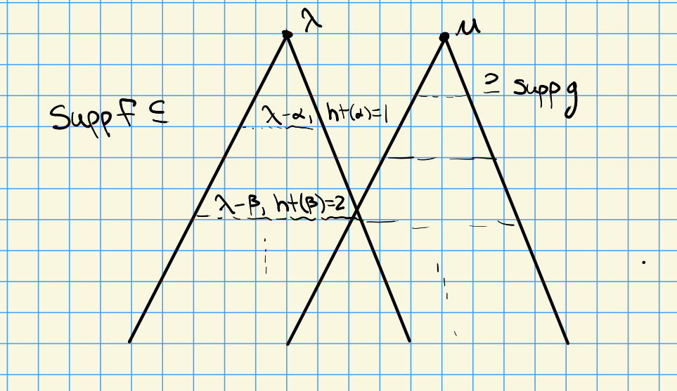

Write $e( \lambda)$ as $e_{ \lambda}$ for $\lambda \in H {}^{ \vee }$, regarded as a function $e_ \lambda:H {}^{ \vee }\to {\mathbf{C}}$ where $e_ \lambda( \mu) = \delta_{ \lambda = \mu}$ is the characteristic function of $\lambda$, and note that $e_ \lambda \ast e_ \mu = e_ { \lambda+ \mu}$. Let $p = \operatorname{ch}_{M(0)}: H {}^{ \vee }\to {\mathbf{C}}$, then
$$\begin{align*}
M(0) = {\mathcal{U}}(L) \otimes_{{\mathcal{U}}(B)} {\mathbf{C}}_0 \cong {\mathcal{U}}(N^-) \otimes_{\mathbf{C}}{\mathbf{C}}_0 \quad\in {}_{H}{\mathsf{Mod}}, {}_{N^-}{\mathsf{Mod}}
.\end{align*}
By PBW, \({\mathcal{U}}(N^-)\) has a basis \(y_{\beta_1}^{i_1}\cdots y_{ \beta_m}^{i_m}\) for \(i_j\in {\mathbf{Z}}_{\geq 0}\) where \(\Phi^+ = \left\{{ {\beta }_{1}, \cdots, {\beta }_{m} }\right\}\). The weights of \(M(0)\) are \(\mu = - \sum_{j=1}^m i_j \beta_j\) and \(\mu\in 0_{\leq}\). Note \(\operatorname{ch}_{M(0)}( \mu) = \dim M(0)_ \mu\), and so \(\operatorname{ch}_{M(0)}\in {\mathcal{X}}\) and thus \(p\in {\mathcal{X}}\).$$

# 42 Friday, December 02

## 42.1 Convolution Formulas

Last time:
$$\begin{align*}
{\mathcal{X}}\mathrel{\vcenter{:}}=\left\{{f\in \mathop{\mathrm{Hom}}_{\mathbf{C}}(H {}^{ \vee }, {\mathbf{C}}) {~\mathrel{\Big\vert}~}\mathop{\mathrm{supp}}f \subseteq \bigcup_{i=1}^n (\lambda_i - {\mathbf{Z}}_{\geq 0} \Phi^+) }\right\}
,\end{align*}
which is a commutative associative unital algebra under convolution, where \(e_{ \lambda}(\mu) = \delta_{ \lambda \mu}\) for \(\mu\in H {}^{ \vee }\) and \(e_ \lambda\ast e_ \mu = e_{ \lambda+ \mu}\) with \(e_0 = 1\). We have \(\operatorname{ch}_{M(0)}\) which records weights \(\mu = \sum_{i=1}^m -i_j \beta_j\) with \(i_j\in {\mathbf{Z}}_{\geq 0}\), and
\begin{align*}
\dim M(0)_\mu \mathrel{\vcenter{:}}=\operatorname{ch}_{M(0)}(\mu) = {\sharp}\left\{{\mathbf{i} \in {\mathbf{Z}}_{\geq 0}^m {~\mathrel{\Big\vert}~}\sum i_j \beta_j = -\mu }\right\} \mathrel{\vcenter{:}}= p(\mu)
\end{align*}
which is the Kostant function – its negative is the Kostant partition function, which records the number of ways of writing a weight as a sum like this. We’ll regard finding such a count as a known or easy problem, since this can be done by enumeration.$$

Define the **Weyl function** $q\mathrel{\vcenter{:}}=\prod_{\alpha \in \Phi^+} (e_{\alpha\over 2} - e_{-{\alpha \over 2}})$ where the product is convolution. For $\alpha\in \Phi+, f_ \alpha:H {}^{ \vee }\to {\mathbf{Z}}$, define
$$\begin{align*}
f_ \alpha( \lambda) \mathrel{\vcenter{:}}=
\begin{cases}
1 & \lambda = -k \alpha \text{ for some } k\in {\mathbf{Z}}_{\geq 0}
\\
0 & \text{otherwise}.
\end{cases}
.\end{align*}
We can regard this as an infinite sum \(f_ \alpha = e_0 + e_{ - \alpha} + e_{ -2 \alpha} + \cdots = \sum_{k\geq 0} e_{ -k \alpha}\).$$

1. $p = \prod_{ \alpha\in \Phi^+} f_ \alpha$,
2. $(e_0 - e_{- \alpha}) \ast f_ \alpha = e_0$,
3. $q = e_\rho \ast\prod_{ \alpha\in \Phi^+} (e_0 - e_{ - \alpha})$.

**Part a**: The coefficient of $e_\mu$ in $\prod_{i=1}^m f_{ \beta_j}$ is the convolution
$$\begin{align*}
\sum_{i_1,\cdots, i_m \in {\mathbf{Z}}_{\geq 0}, -\sum i_j \beta_j = \mu } f_{\beta_1}(-i_1 \beta_1) \cdots f_{ \beta_m }(-i_m \beta_m) = p(\mu)
.\end{align*}$$

**Part b**:
$$\begin{align*}
(e_0 - e_{- \alpha}) \ast(e_0 + e_{- \alpha} + e_{-2 \alpha} + \cdots)
= e_0 + e_{ - \alpha} - e_{ - \alpha}+ e_{ -2 \alpha}- e_{ -2 \alpha} +\cdots = e_0
,\end{align*}
noting the telescoping. This can be checked rigorously by regarding these as functions instead of series.$$

**Part c**: Recall $\rho = \sum_{ \alpha\in \Phi^+} {1\over 2}\alpha$, so $e_\rho = \prod_{ \alpha\in \Phi^+} e_{\alpha\over 2}$. Thus the RHS is
$$\begin{align*}
\prod_{ \alpha\in \Phi^+} \qty{e_{\alpha\over 2} \ast(e_0 - e_{- \alpha}) } = \prod_{\alpha\in \Phi^+}(e_{\alpha\over 2} - e_{- \alpha\over 2} ) \mathrel{\vcenter{:}}= q
.\end{align*}
Note that \(q\neq 0\) since \(q(\rho) = 1\).$$

Let $w\in W$, recalling that $w.e_{\alpha} = e_{w \alpha}$,
$$\begin{align*}
wq = (-1)^{\ell(w)} q
.\end{align*}$$

ETS for $\alpha \in \Delta$. Recall $s_ \alpha$ permutes $\Phi^+ \setminus\left\{{ \alpha }\right\}$ and $s_ \alpha(\alpha) = - \alpha$, so $s_ \alpha q$ permutes the factors $(e_{ \beta\over 2} - e_{-{\beta\over 2}})$ for $\beta\neq \alpha$ and negates $e_{\alpha\over 2} - e_{- \alpha\over 2}$.

Use lemma A:
$$\begin{align*}
q\ast\rho \ast e_{-\rho}
&= e_\rho \ast\qty{ \prod_{ \alpha\in \Phi^+} (e_0 - e_{ - \alpha} ) } \ast p \ast e_{ - \rho} \qquad \text{by C} \\
&= \qty{ \prod_{ \alpha\in \Phi^+} (e_0 - e_{ - \alpha} ) } \ast p \\
&= \qty{ \prod_{ \alpha\in \Phi^+} (e_0 - e_{ - \alpha}) \ast f_{ \alpha} } \qquad \text{by A}\\
&= \prod_{ \alpha\in \Phi^+} e_0 \qquad \text{by B}\\
&= e_0
.\end{align*}$$

For $\lambda, \mu\in H {}^{ \vee }$,
$$\begin{align*}
\operatorname{ch}_{M( \lambda)}( \mu) = p( \mu - \lambda) = (p \ast e_ \lambda)( \mu) \implies \operatorname{ch}_{M( \lambda)} = p \ast e_{ \lambda}
.\end{align*}$$

$M( \lambda)$ has basis $y_{\beta_1}^{i_1}\cdots y_{ \beta_m}^{i_m} \cdot v^+$ where $v^+$ is a highest weight vector of weight $\lambda$. Note that
$$\begin{align*}
\mu = \lambda- \sum_{j=1}^M i_j \beta_j \iff \mu- \lambda= - \sum_{i=1}^m i_j \beta_j
,\end{align*}
and \(\dim M(\lambda)_ \mu = p( \mu- \lambda)\). Now check \((p\ast e_ \lambda)( \mu) \mathrel{\vcenter{:}}= p( \mu - \lambda) e_ \lambda(\lambda) = p( \mu- \lambda)\).$$

$$\begin{align*}
q \ast\operatorname{ch}_{M( \lambda)} = e_{ \lambda+ \rho}
.\end{align*}$$

$$\begin{align*}
\text{LHS}
\overset{D}{=} q \ast p \ast e_ \lambda
\overset{C}{=} e_ \rho \ast e_ \lambda = e_{ \lambda+ \rho}
.\end{align*}$$

## 42.2 $\S 24.2$ Kostant’s Multiplicity Formula

Recall that characters of Verma modules are essentially known. For $\lambda\in \Lambda^+$, we have $\operatorname{ch}_{ \lambda} \mathrel{\vcenter{:}}=\operatorname{ch}_{L( \lambda)}$, recalling that $L( \lambda)$ is a finite-dimensional irreducible representation. Goal: express this as a finite ${\mathbf{Z}}{\hbox{-}}$linear combination of certain $\operatorname{ch}_{M( \lambda)}$.

Fix $\lambda\in H {}^{ \vee }$ and let ${\mathcal{M}}_ \lambda$ be the collection of all $L{\hbox{-}}$modules satisfying the following:

1. $V = \bigoplus _{ \mu\in H {}^{ \vee }} V_ \mu$,
2. ${\mathcal{Z}}(L)\curvearrowright V$ by $\chi_ \lambda$,
3. $\operatorname{ch}_V \in {\mathcal{X}}$

Note that any highest weight module of highest weight $\lambda$ is in ${\mathcal{M}}_ \lambda$, and this is closed under submodules, quotients, and finite direct sums. The Harish-Chandra theorem implies that
$$\begin{align*}
{\mathcal{M}}_ \lambda = {\mathcal{M}}_{\mu} \iff \lambda\sim \mu\iff \mu = w. \lambda
.\end{align*}$$

If $0\neq V \in {\mathcal{M}}_ \lambda$ then $V$ has a maximal vector.

By (3), the weights of $V$ lie in a finite number of cones $\lambda_i - {\mathbf{Z}}_{\geq 0} \Phi^+$. So if $\mu$ is a weight of $V$ and $\alpha\in \Phi^+$, then $\mu + k \alpha$ is not a weight of $V$ for $k\gg 0$. Iterating this for the finitely many positive weights, there exists a weight $\mu$ such that $\mu + \alpha$ is not a weight for any $\alpha\in \Phi^+$. Then any $0\neq v\in V_ \mu$ is a maximal vector.

For $\lambda \in H {}^{ \vee }$, set
$$\begin{align*}
\Theta( \lambda) \mathrel{\vcenter{:}}=\left\{{ \mu\in H {}^{ \vee }{~\mathrel{\Big\vert}~}\mu\sim \lambda\, \text{ and } \, \mu\leq \lambda}\right\}
,\end{align*}
which by the Harish-Chandra theorem is a subset of \(W\cdot \lambda\) which is a finite set.$$

The following tends to hold in any setting with “standard” modules, e.g. quantum groups or superalgebras:

Let $\lambda\in H {}^{ \vee }$, then

1. $M( \lambda)$ has a composition series,
2. Each composition factor of $M( \lambda)$ is of the form $L( \mu)$ for some $\mu\in \Theta( \lambda)$. Define $[M (\lambda): L( \mu)]$ to be the multiplicity of $L(\mu)$ as a composition factor of $M( \lambda)$.
3. $[M( \lambda): L( \lambda)] = 1$.

By induction on the number of maximal vectors (up to scalar multiples). If $M( \lambda)$ is irreducible then it’s an irreducible highest weight module, and these are unique up to isomorphism and so $M( \lambda) = L( \lambda)$ and we’re done. Otherwise $M( \lambda)$ has a proper irreducible submodule $V$, and $V\in {\mathcal{M}}_ \lambda$ by closure under submodules. By the lemma, $V$ has a maximal vector of some weight $\mu$ which must be strictly less than $\lambda$, i.e. $\mu < \lambda$. As before, $\chi_{ \mu} = \chi_ \lambda$ and thus $\mu\in \Theta( \lambda)$. Consider $V$ and $M( \lambda)/ V$ – each lies in ${\mathcal{M}}_ \lambda$ and either has fewer weights linked to $\lambda$ than $M( \lambda)$ has, or else it must have exactly the same set of weights linked to $\lambda$, just with smaller multiplicities. By induction each of these has a composition series, and these can be pieced together into a series for $M$ since they fit into a SES.

# 43 Monday, December 05

## 43.1 Kostant’s Character Formula

Last time: ${\mathcal{M}}_ \lambda$ defined as a certain category of $L{\hbox{-}}$modules for $\lambda\in H {}^{ \vee }$, and we defined $\theta( \lambda) \mathrel{\vcenter{:}}=\left\{{ \mu\in H {}^{ \vee }{~\mathrel{\Big\vert}~}\mu \sim \lambda,\,\, \mu\leq \lambda}\right\} \subseteq W. \lambda$. Proposition from last time:

Note that any character of $M$ is the sum of the characters of its composition factors.

**Part b**: Each composition factor of $M( \lambda)$ is in ${\mathcal{M}}_ \lambda$, hence by the lemma has a maximal vector. Since it’s irreducible, it is a highest weight module $L( \mu)$ for some $\mu\in \theta( \lambda)$.

**Part c**: $[M( \lambda) : L( \lambda)] = 1$ since $\dim M( \lambda)_ \lambda = 1$ and all other weights are strictly less than $\lambda$.

Order $\theta( \lambda) = \left\{{ \mu_1, \cdots, \mu_t}\right\}$ such that $\mu_\leq \mu_j \implies i\leq j$. In particular, $\mu_t = \lambda$. By the proposition, $\operatorname{ch}_{M( \mu_j)}$ is a ${\mathbf{Z}}_{\geq 0}{\hbox{-}}$linear combination of $\operatorname{ch}_{L(\mu_i)}$ where $i\leq j$, and the coefficient of $\operatorname{ch}_{L(\mu_j)}$ is 1. Recording multiplicities in a matrix, we get the following:

[figure not shown]

This is an upper triangular unipotent matrix, and thus invertible.

Let $\lambda \in H {}^{ \vee }$, then
$$\begin{align*}
\operatorname{ch}_{L( \lambda)} = \sum_{ \mu \in \theta( \lambda)} c( \mu) \operatorname{ch}_{M( \mu)}, \qquad c( \mu)\in {\mathbf{Z}}, \, c( \lambda) = 1
.\end{align*}$$

Assume $\lambda\in \Lambda^+$, and recall:

- ${\mathcal{X}}= \left\{{f: H {}^{ \vee }\to {\mathbf{C}}{~\mathrel{\Big\vert}~}\text{ the "forest" support condition }}\right\}$,
- $p=\operatorname{ch}_{M(0)}$,
- $p(\mu) = {\sharp}\left\{{ {\left[ {i_1:\cdots:i_m} \right]} \in {\mathbf{Z}}_{\geq 0}^m }\right\}$,
- $q\mathrel{\vcenter{:}}=\prod_{ \alpha\in \Phi^+} (e_{\alpha\over 2} - e_{-{\alpha\over 2}})$,
- $\mu = -\sum_{1\leq j\leq m} i_j \beta_j$,
- $wq = (-1)^{\ell(w)} q$ for $w\in W$,
- $q \ast p \ast e_{-\rho} = e_0$,
- $\operatorname{ch}_{M(\lambda)} = p \ast e_ \lambda$,
- $q \ast\operatorname{ch}_{M( \lambda) } = e_{ \lambda+ \rho}$,
- $\operatorname{ch}_ \lambda\mathrel{\vcenter{:}}=\operatorname{ch}_{L( \lambda)} = \sum_{ \mu\in \theta( \lambda)} c( \mu) \operatorname{ch}_{M( \mu)}$,
- $q\ast\operatorname{ch}_{L( \lambda)} = \sum c( \mu) q \ast\operatorname{ch}_{M( \mu)} = \sum c( \mu) e_{ \mu + \rho}$. $\qquad\star_1$

Fixing $w\in W$, we have
$$\begin{align*}
\sum_{ \mu\in \theta( \lambda) } c( \mu) e_{w (\lambda+ \rho)}
&= w( q \ast\operatorname{ch}_ \lambda) \\
&= wq \ast w \operatorname{ch}_{ \lambda} \\
&= (-1)^{\ell(w)} q \operatorname{ch}_ \lambda \qquad \text{since $\operatorname{ch}_ \lambda$ is $W{\hbox{-}}$invariant} \\
&= (-1)^{\ell(w)} \sum_ \mu c( \mu) e_{ \mu+ \rho}
.\end{align*}
Since \(\lambda\in \Lambda^+\), \(W\) acts simply transitively on \(\theta( \lambda) + \rho \mathrel{\vcenter{:}}=\left\{{v+\rho {~\mathrel{\Big\vert}~}v\in \theta( \lambda) }\right\}\). Note \(\mu \sim \lambda\iff \mu+ \rho = w( \lambda+ \rho)\) for some \(w\in W\), which is unique since \(\lambda+ \rho\) is strongly/strictly dominant, and lemma 13.2A shows its stabilizer is the identity. So \({\operatorname{Stab}}_W( \lambda+ \rho) = \left\{{1}\right\}\). The equation \(\mu + \rho = w( \lambda+ \rho)\) implies \(\mu + \rho \leq \lambda+ \rho\), since apply \(W\) to dominant elements goes down in the partial order. Thus \(\mu\in \theta(\lambda)\), and \(\theta( \lambda)\) consists of precisely those \(\mu\) satisfying this equation, and
\begin{align*}
\theta( \lambda) = W\cdot \lambda
.\end{align*}$$

Continuing the computation, take $\mu = \lambda$ on the LHS, so $w( \lambda+ \rho) = \mu+ \rho$ and
$$\begin{align*}
c( \lambda) e_{w( \lambda+ \rho)} = (-1)^{\ell(w)} c( \mu) e_{ \mu+ \rho}\implies c(\mu) = (-1)^{\ell(w)} c( \lambda)
.\end{align*}$$

Substituting this into $\star_1$ yields
$$\begin{align*}
q \ast\operatorname{ch}_ \lambda = \sum_{w\in W} (-1)^{\ell(w)} e_{w ( \lambda+ \rho)} \qquad \star_2
,\end{align*}
so
\begin{align*}
\operatorname{ch}_ \lambda
&= q \ast p \ast e_{ - \rho} \ast\operatorname{ch}_ \lambda\\
&= p \ast e_{- \rho} \ast\sum_{w\in W} (-1)^{\ell(w)} e_{w (\lambda+ \rho)} \\
&= \sum_{w\in W} (-1)^{\ell(w)} p \ast e_{w( \lambda+ \rho) - \rho}
&= \sum_{w\in W} (-1)^{\ell(w)} p \ast e_{w\cdot \lambda}
.\end{align*}$$

This yields the following:

For $\lambda\in \Lambda^+$ dominant, the weight multiplicities in $L( \lambda)$ are given by
$$\begin{align*}
\dim L( \lambda)_\mu \mathrel{\vcenter{:}}= m_ \lambda( \mu)
= \sum_{w\in W} (-1)^{\ell(w)} p( \mu+ \rho - w( \lambda+ \rho))
= \sum_{w\in W} (-1)^{\ell(w)} p( \mu - w\cdot \lambda)
.\end{align*}$$

## 43.2 $\S 24.3$ Weyl’s Character Formula

$$\begin{align*}
q = \sum_{w\in W} (-1)^{\ell(w)} e_{w \rho}
.\end{align*}$$

Take $\lambda = 0$ in $\star_2$, and use that $\operatorname{ch}_0 = e_0$ where $L(0) \cong {\mathbf{C}}$.

Let $\lambda \in \Lambda^+$, then
$$\begin{align*}
\qty{ \sum_{w\in W} (-1)^{ \ell(w)} e_{w\rho} } \ast\operatorname{ch}_{L( \lambda)} = \sum_{w\in W} (-1)^{\ell(w)} e_{w( \lambda+ \rho)}
.\end{align*}$$

Apply $\star_2$ and the lemma.

$$\begin{align*}
\dim L( \lambda) = { \prod_{ \alpha\in \Phi^+} {\left\langle { \lambda+ \rho},~{ \alpha} \right\rangle} \over\prod_{\alpha\in \Phi^+} {\left\langle {\rho },~{\alpha } \right\rangle}} = \sum_{ \mu \in \Pi( \lambda)} m_ \lambda( \mu)
.\end{align*}$$

# 44 Tuesday, December 06

## 44.1 Weyl Dimension Formula

Last time:

- $q \mathrel{\vcenter{:}}=\sum_{ \alpha\in \Phi^+} (e_{\alpha\over 2} - e_{-{\alpha\over 2}}) = \sum_{w\in W} (-1)^{\ell(w)} e_{w \rho}$.
- The WCF: $q\ast\operatorname{ch}_{ \lambda} = \sum_{w\in W} (-1)^{\ell(w)} e_{w ( \lambda+ \rho)}$
- An alternative writing of the WCF: \begin{align*} \operatorname{ch}_ \lambda= { \sum_{w\in W} (-1)^{\ell(w)} e_{w (\lambda+ \rho)} \over \sum_{w\in W} (-1)^{\ell(w)} e_{w \rho}} ,\end{align*} where the denominator is denoted the *Weyl denominator*.

$$\begin{align*}
\dim L( \lambda) = { \prod_{ \sigma\in \Phi^+} {\left\langle { \lambda+ \rho},~{ \alpha} \right\rangle} \over \prod_{ \alpha\in \Phi^+} {\left\langle {\rho },~{\alpha } \right\rangle}}
,\end{align*}
which is a quotient of two integers.$$

Show that $W$ always has an equal number of even and odd elements, so $\sum_{w\in W} (-1)^{\ell(w)} = 0$.

Note $\operatorname{ch}_{ \lambda} = \sum _{\mu} \dim L( \lambda)_ \mu e_ \mu\in {\mathbf{Z}}[ \Lambda]$, and $\dim L( \lambda) = \sum_{ \mu\in \Lambda} m_ \lambda( \mu)$. Viewing $\operatorname{ch}_ \lambda: \Lambda\to {\mathbf{Z}}$ as a restriction of a function $H {}^{ \vee }\to {\mathbf{C}}$, $\dim L( \lambda)$ is the sum of all values of $\operatorname{ch}_ \lambda$. Work in the ${\mathbf{C}}{\hbox{-}}$subalgebra ${\mathcal{X}}_0$ of ${\mathcal{X}}$ generated by the characteristic functions $S \mathrel{\vcenter{:}}=\left\{{e_ \mu{~\mathrel{\Big\vert}~}\mu\in \Lambda}\right\}$; this equals the span of $S$ since $e_{ \mu} \ast e_{\nu} = e_{ \mu+ \nu}$. We have a map
$$\begin{align*}
v: {\mathcal{X}}_0 &\to {\mathbf{C}}\\
f &\mapsto \sum_{ \mu\in \Lambda} f( \mu)
,\end{align*}
which makes sense since \({\sharp}\mathop{\mathrm{supp}}f < \infty\). This function sums the values we’re after, so the goal is to compute \(v( \operatorname{ch}_ \lambda)\). By the exercise, attempting to apply this directly to the numerator and denominator yields \(0/0\), and we get around this by using a variant of L’Hopital’s rule. Define \({\partial}_ \alpha (e_ \mu) = ( \mu, \alpha)e_ \mu\), extended linearly to \({\mathcal{X}}_0\). In the basis \(S\) this operator is diagonal, and this is a derivation relative to convolution:
\begin{align*}
{\partial}_ \alpha \qty{ e_ \mu \ast e_{ \nu} }
&= {\partial}_ \alpha( e_{ \mu+ \nu} ) \\
&= ( \mu+ \nu, \alpha)e_{ \mu+ \nu} \\
&= \qty{ (\mu, \alpha) e_ \mu} \ast e_ \nu + e_ \mu \ast\qty{ (\nu, \alpha) e_ \nu} \\
&= ({\partial}_ \alpha e_ \mu) \ast e_ \nu + e_ \mu \ast({\partial}_{\alpha} e _{\nu})
.\end{align*}
Moreover they commute, i.e. \({\partial}_ \alpha {\partial}_ \beta = {\partial}_{\beta} {\partial}_{\beta}\). Set \({\partial}\mathrel{\vcenter{:}}=\prod_{ \alpha\in \Phi^+} {\partial}_ \alpha\) where the product here is composition, and view \({\partial}\) as an \(m\)th order differential operator. Write \(\omega( \lambda+ \rho)\mathrel{\vcenter{:}}=\sum_{w\in W} (-1)^{\ell(w)} e_{w (\lambda+ \rho)}\) for \(\lambda\in \Lambda^+\), so \(q = \omega ( \rho)\). Rewriting the WCF we have
\begin{align*}
\omega( \rho) \ast\operatorname{ch}_ \lambda = \omega( \lambda+ \rho) \qquad \star_1
,\end{align*}
and
\begin{align*}
\prod_{ \alpha\in \Phi^+}\qty{e_{ \alpha\over 2} - e_{- {\alpha\over 2}}} \ast\operatorname{ch}_ \lambda = \omega( \lambda+ \rho)
.\end{align*}
We now try to apply \({\partial}\) to both sides, followed by \(v\). Note that if any two factors of \({\partial}\) hit the same factor on the LHS, then noting that \(v(e_{\alpha\over 2} - e_{-{ \alpha\over 2}}) = 0\), such terms will vanish. So the total result will be zero unless all of the factors of \({\partial}\) are applied to the \(q\) factor in the LHS.$$

So apply $v\circ {\partial}$ to $\star_1$ to get
$$\begin{align*}
v( {\partial}\omega( \rho)) v( \operatorname{ch}_ \lambda) = v( {\partial}\omega( \lambda+ \rho))
.\end{align*}
We can compute
\begin{align*}
v( {\partial}\omega ( \rho))
= v\qty{ {\partial}\sum_{w\in W} (-1)^{\ell(w)} e_{ w \rho} }
= \sum_{w\in W} (-1)^{\ell(w)} v({\partial}( e_{ w \rho} ) )
.\end{align*}
We have
\begin{align*}
v ( {\partial}( e_{ w \rho}))
&= v\qty{ \qty{ \prod_{\alpha\in \Phi^+} {\partial}_\alpha } e_{ w \rho} } \\
&= v\qty{\prod_{ \alpha\in \Phi^+} (w \rho, \alpha) e_{ w \rho} } \\
&= \prod_{ \alpha\in \Phi^+} ( w \rho, \alpha) \\
&= \prod_{ \alpha\in \Phi^+} ( \rho, w^{-1}\alpha) \qquad \star_2
.\end{align*}
Note that \(w^{-1}\cdot \Phi^+\) is a permutation of \(\Phi^+\), just potentially with some signs changed – in fact, exactly \(n(w^{-1})\), the number of positive roots sent to negative roots, and \(n(w^{-1}) = \ell(w^{-1})\). Thus the above is equal to
\begin{align*}
(-1)^{\ell(w)} \prod_{ \alpha\in \Phi^+}( \rho, \alpha)
.\end{align*}
Continuing \(\star_2\), we have
\begin{align*}
v( {\partial}( e_{ w \rho}))
&= \sum_{w\in W} (-1)^{\ell(w)} (-1)^{\ell(w)} \prod_{ \alpha\in \Phi^+}( \rho, \alpha) \\
&= {\sharp}W \prod_{ \alpha\in \Phi^+}( \rho, \alpha)
,\end{align*}
which is the LHS. Similarly for the RHS,
\begin{align*}
v({\partial}( \lambda+ \rho)) = {\sharp}W \prod_{ \alpha\in \Phi^+} (\lambda+ \rho, \alpha)
.\end{align*}$$

If $\alpha\in \Phi^+$, using that $\alpha {}^{ \vee }$ is a basis of $\Phi {}^{ \vee }$, one can write $\alpha {}^{ \vee }= \sum_{i=1}^\ell c_i^{ \alpha} \alpha_i {}^{ \vee }$ for some $c_{i}^{\alpha} \in {\mathbf{Z}}_{\geq 0}$ and $\lambda = \sum_{i=1}^\ell m_i \lambda_i$ for $m_i \in {\mathbf{Z}}_{ \geq 0}$, using that $( \rho, \alpha_i {}^{ \vee }) = {\left\langle { \rho},~{ \alpha_i} \right\rangle} = 1$ one can rewrite the dimension formula in terms of the integers $c_i^{\alpha}$ and $m_i$.

## 44.2 New Directions

Where you could go after studying semisimple finite-dimensional Lie algebras over ${\mathbf{C}}$:

- Infinite-dimensional representations of such algebras, e.g. the Verma modules $M( \lambda)$. One has a SES $K( \lambda) \hookrightarrow M( \lambda) \twoheadrightarrow L( \lambda)$, which doesn’t split since $M( \lambda)$ is indecomposable.
- Category ${\mathcal{O}}$, expressing characters of simples in terms of characters of Vermas.
- Parabolic versions of Verma modules: we’ve looked at modules induced from $B = H + N$, but one could look at parabolics $P = U + \sum L_i$.
- Coxeter groups, i.e. groups generated by reflections, including Weyl groups. These can be infinite, which ones are finite?
- Quantize Coxeter groups to get Hecke algebras, which are algebras over ${\mathbf{C}}[q, q^{-1}]$. See Humphreys.
- Representations of Lie groups over ${\mathbf{R}}$, semisimple algebraic groups, representations of finite groups of Lie type (see the classification of finite simple groups, e.g. algebraic groups over finite fields).
- Characteristic $p$ representation theory, which is much more difficult.
- Infinite-dimensional Lie algebras over ${\mathbf{C}}$, e.g. affine/Kac-Moody algebras using the Serre relations on generalized Cartan matrices. See also current algebras, loop algebras.
- Quantum groups (quantized enveloping algebras), closely tied to modular representation theory.

# 45 Useful Tricks

- $[[xy]z] = [x[yz]] + [[xz]y] = [x[yz]] - [y[xz]]$.
- $xz.w = zx.w + [xz].w$.
- If $N, M$ are upper triangular, $[NM]$ has zeros along the diagonal.

# 46 Summary of main results

## 46.1 Computation

- Bracketing elementary matrices:
  $$\begin{align*}
  [e_{ij}, e_{kl}] = \delta_{jk} e_{il} - \delta_{li} e_{kj}
  .\end{align*}$$

## 46.2 Classical Algebras

$$\begin{align*}
x=\left(\begin{array}{ll}0 & 1 \\ 0 & 0\end{array}\right)\quad
h=\left(\begin{array}{cc}
1 & 0 \\
0 & -1
\end{array}\right)
y=\left(\begin{array}{ll}0 & 0 \\ 1 & 0\end{array}\right)\quad \\ \\
[x, y]=h, \quad[h, x]=2 x, \quad[y, h]=2 y
.\end{align*}
- \({\mathfrak{sl}}_n({ \mathbf{F} })\) is dimension \(n^2-1\) and corresponds to type \(A_{n-1}\).$$

## 46.3 Definitions

- $N_L(S) = \left\{{x\in L {~\mathrel{\Big\vert}~}[xS] \subseteq S}\right\}$.
- $C_L(S) = \left\{{x\in L {~\mathrel{\Big\vert}~}[x S] = 0}\right\}$.
- $L$ is simple iff $L\neq 0$ and $\operatorname{Id}(L) = \left\{{0, L}\right\}$.
- $L$ is solvable iff $L^{(n+1)} \mathrel{\vcenter{:}}=[ L^{(n)} L^{(n)}] \overset{n\to\infty}\to 0$.
- $L$ is semisimple iff $\mathop{\mathrm{Rad}}(L) \mathrel{\vcenter{:}}=\sum_{I {~\trianglelefteq~}L \text { solvable}} I = 0$.
- $L$ is nilpotent iff $L^{n+1} \mathrel{\vcenter{:}}=[L L^{n-1}] \overset{n\to\infty}\to 0$.
- The Killing form is $\kappa(x,y)\mathrel{\vcenter{:}}=\operatorname{Trace}( { \operatorname{ad}}_x \circ { \operatorname{ad}}_y)$.
- Checking ${\mathsf{L}{\hbox{-}}\mathsf{Mod}}$ actions:
  - $( \lambda_1 x + \lambda_2 y).\mathbf{v} = \lambda_1 (x.\mathbf{v}) + \lambda_2(y.\mathbf{v})$
  - $x.(\lambda_1 \mathbf{v}+ \lambda_2 \mathbf{w}) = \lambda_1 (x.\mathbf{v}) + \lambda_2(x.\mathbf{w})$
  - $[xy].\mathbf{v} = x.(y.\mathbf{v}) - y.(x.\mathbf{v})$. This is the axiom that introduces weird formulas for homs/tensors/duals.
- Duals: $(x.f)(\mathbf{v}) \mathrel{\vcenter{:}}=-f(x.\mathbf{v})$
- Tensors: $x.(\mathbf{v}\otimes\mathbf{w}) \mathrel{\vcenter{:}}=\qty{ (x.\mathbf{v})\otimes\mathbf{w}} + \qty{\mathbf{v}\otimes(x.\mathbf{w})}$.
- The Casimir element: for $\phi: L\to {\mathfrak{gl}}(V)$ an irreducible representation of $L$ semisimple, define $\beta(x, y) \mathrel{\vcenter{:}}=\operatorname{Trace}(\phi(x)\circ \phi(y))$. Pick a basis and dual basis $\left\{{e_i}\right\}, \left\{{e_i {}^{ \vee }}\right\}$ with respect to $\beta$ and define $c_\phi(\beta) \mathrel{\vcenter{:}}=\sum \phi(e_i)\phi(e_i {}^{ \vee }) \in { \operatorname{End} }(V)$.
  - This is an endomorphism of $V$ commuting with the $L{\hbox{-}}$action which has nonzero trace.

## 46.4 Results

- Engel’s theorem: if every $x\in L$ is ad-nilpotent then $L$ is nilpotent.
  - Since conversely (for free) $L$ nilpotent implies ${ \operatorname{ad}}_x$ is nilpotent for every $x$, this becomes an iff: $L$ is nilpotent iff every $x\in L$ is ad-nilpotent.
- Lie’s theorem: if $L\leq {\mathfrak{gl}}(V)$ is solvable then $L$ stabilizes a flag in $V$ (i.e. $L$ has an upper triangular basis).
- Cartan’s criterion: if $L\leq {\mathfrak{gl}}(V)$ and $\operatorname{Trace}(xy) = 0$ for all $x\in [LL]$ and $y\in L$, then $L$ is solvable.
- $L$ is semisimple iff $\kappa_L$ is nodegenerate.
- If $L$ is semisimple, it decomposes as $L = \bigoplus L_i$ where the $L_i$ are uniquely determined simple ideals, and every simple ideal of $L$ is one such $L_i$.
- $\ker (L \xrightarrow{ { \operatorname{ad}}_L} {\mathfrak{gl}}(V)) = Z(L)$ and simple algebras are centerless, so any simple Lie algebra is isomorphic to a linear Lie algebra ${\mathfrak{gl}}(V)$ for some $V$, namely $\operatorname{im} { \operatorname{ad}}_L$.
- Schur’s lemma: if $L \xrightarrow{\phi} {\mathfrak{gl}}(V)$ is an irreducible representation, then $C_{{\mathfrak{gl}}(V)}(\phi(L)) = {\mathbf{C}}I$, i.e. the only endomorphisms of $V$ commuting with every $\phi(x)$ are scalar operators. Equivalently, ${ \operatorname{End} }_L(V) \cong {\mathbf{C}}$.
- Weyl’s theorem: if $L$ is semisimple and $\phi: L\to {\mathfrak{gl}}(V)$ is a finite-dimensional representation then $\phi$ is completely reducible.

# 47 Problem Set 1

## 47.1 Section 1

Let $L$ be the real vector space $\mathbf{R}^{3}$. Define $[x y]=x \times y$ (cross product of vectors) for $x, y \in L$, and verify that $L$ is a Lie algebra. Write down the structure constants relative to the usual basis of $\mathbf{R}^{3}$.

It suffices to check the 3 axioms given in class that define a Lie algebra:

- **L1 (Bilinearity)**: This can be quickly seen from the formula
  $$\begin{align*}
  a\times b = {\left\lVert {a} \right\rVert}\cdot {\left\lVert {b} \right\rVert}\sin(\theta_{ab}) \widehat{n}_{ab}
  \end{align*}
  where \(\widehat{n}_{ab}\) is the vector orthogonal to both \(a\) and \(b\) given by the right-hand rule. The result follows readily from a direct computation:
  \begin{align*}
  (ra)\times(tb)
  &= {\left\lVert {ra} \right\rVert} \cdot {\left\lVert {tb} \right\rVert} \sin(\theta_{ra, tb}) \widehat{n}_{ra, tb} \\
  &= (rt) {\left\lVert {a} \right\rVert} \cdot {\left\lVert {b} \right\rVert} \sin(\theta_{a, b}) \widehat{n}_{a, b} \\
  &= (rt)\qty{a\times b}
  ,\end{align*}
  where we’ve used the fact that the angle between \(a\) and \(b\) is the same as the angle between any of their scalar multiples, as is their normal.$$
- **L2**: that $a\times a = 0$ readily follows from the same formula, since $\sin( \theta_{a, a}) = \sin(0) = 0$.
- **L3 (The Jacobi identity)**: This is most easily seen from the “BAC - CAB” formula,
  $$\begin{align*}
  a\times (b\times c) = b{\left\langle {a},~{c} \right\rangle} - c{\left\langle {a},~{b} \right\rangle}
  .\end{align*}
  We proceed by expanding the Jacobi expression:
  \begin{align*}
  a\times(b\times c) + c\times (a\times b) + b\times (c\times a)
  &= {\color{blue} b{\left\langle {a},~{c} \right\rangle} } - {\color{red} c{\left\langle {a},~{b} \right\rangle} }\\
  &\quad + {\color{green} a {\left\langle { c },~{ b } \right\rangle} } - {\color{blue} b {\left\langle { c },~{ a } \right\rangle} } \\
  &\quad + {\color{red} c {\left\langle { a },~{ b } \right\rangle} } - {\color{green} a {\left\langle { b },~{ c } \right\rangle} } \\
  &= 0
  .\end{align*}$$

For the structure constants, let $\left\{{e_1, e_2, e_3}\right\}$ be the standard Euclidean basis for ${\mathbf{R}}^3$; we can then write $e_i\times e_j = \sum_{k=1}^3 c_{ij}^k e_k$ and we would like to determine the $c_{ij}^k$. One can compute the following multiplication table:

| $e_i\times e_j$ | $e_1$ | $e_2$ | $e_3$ |
| --- | --- | --- | --- |
| $e_1$ | $0$ | $e_3$ | $-e_2$ |
| $e_2$ | $-e_3$ | $0$ | $e_1$ |
| $e_3$ | $e_2$ | $-e_1$ | $0$ |

Thus the structure constants are given by the antisymmetric Levi-Cevita symbol,
$$\begin{align*}
c_{ij}^k = {\varepsilon}^{ijk} \mathrel{\vcenter{:}}=
\begin{cases}
0 & \text{if any index $i,j,k$ is repeated}
\\
\operatorname{sgn}\sigma_{ijk} & \text{otherwise},
\end{cases}
\end{align*}
where \(\sigma_{ijk} \in S_3\) is the permutation associated to \((i, j, k)\) in cycle notation and \(\operatorname{sgn}\sigma\) is the sign homomorphism.$$

An example to demonstrate how the Levi-Cevita symbol works:

$$\begin{align*}
e_1\times e_2 = c_{12}^1 e_1 + c_{12}^2 e_2 + c_{12}^3 e_3 = 0 e_1 + 0 e_2 + 1e_3
\end{align*}
since the first two terms have a repeated index and
\begin{align*}
c_{12}^3 = {\varepsilon}_{1,2,3} = \operatorname{sgn}(123) = \operatorname{sgn}(12)(23) = (-1)^2 = 1
\end{align*}
using that \(\operatorname{sgn}\sigma = (-1)^m\) where \(m\) is the number of transpositions in \(\sigma\).$$

Let $x \in {\mathfrak{gl}}_n({ \mathbf{F} })$ have $n$ distinct eigenvalues $a_{1}, \ldots, a_{n}$ in ${ \mathbf{F} }$. Prove that the eigenvalues of ${ \operatorname{ad}}_x$ are precisely the $n^{2}$ scalars $a_{i}-a_{j}$ for $1 \leq i, j \leq n$, which of course need not be distinct.

For a fixed $n$, let $e_{ij} \in {\mathfrak{gl}}_n({ \mathbf{F} })$ be the matrix with a 1 in the $(i, j)$ position and zeros elsewhere. We will use the following fact: \begin{align*} e_{ij} e_{kl} = \delta_{jk} e_{il} ,\end{align*} where $\delta_{jk} = 1 \iff j=k$, which implies that \begin{align*} [e_{ij} e_{kl} ] = e_{ij}e_{kl} - e_{kl}e_{ij} = \delta_{jk} e_{il} - \delta_{li}e_{kj} .\end{align*} Suppose without loss of generality[^20] that $x$ is diagonal and of the form $x = \operatorname{diag}(a_1, a_2, \cdots, a_n)$. Then the eigenvectors of $x$ are precisely the $e_{ij}$, since a direct check via matrix multiplication shows $xe_{ij} = a_i e_{ij}$.

When $\operatorname{ch}{ \mathbf{F} }=0$, show that each classical algebra $L=\mathrm{A}_{\ell}, \mathrm{B}_{\ell}, \mathrm{C}_{\ell}$, or $\mathrm{D}_{\ell}$ is equal to $[L L]$. (This shows again that each algebra consists of trace 0 matrices.)

We will check for this type $A_n$, corresponding to $L \mathrel{\vcenter{:}}={\mathfrak{sl}}_{n+1}$. Since $[LL] \subseteq L$, it suffices to show $L \subseteq [LL]$, and we can further reduce to writing every basis element of $L$ as a commutator in $[LL]$. Note that $L$ has a standard basis given by the matrices

- $\left\{{x_i \mathrel{\vcenter{:}}= e_{ij} {~\mathrel{\Big\vert}~}i > j}\right\}$ corresponding to ${\mathfrak{n}}^-$,
- $\left\{{h_i \mathrel{\vcenter{:}}= e_{ii} - e_{i+1, i+1} {~\mathrel{\Big\vert}~}1\leq i \leq n}\right\}$ corresponding to ${\mathfrak{h}}$, and
- $\left\{{y_i \mathrel{\vcenter{:}}= e_{ij} {~\mathrel{\Big\vert}~}i < j}\right\}$ corresponding to ${\mathfrak{n}}^+$.

Considering the equation $[e_{ij} e_{kl} ] = \delta_{jk} e_{il} - \delta_{li}e_{kj}$, one can choose $j=k$ to preserve the first term and $l\neq i$ to kill the second term. So letting $t, i, j$ be arbitrary with $i\neq j$, we have
$$\begin{align*}
[e_{it} e_{tj}] = \delta_{tt} e_{ij} - \delta_{ij}e_{tt} = e_{ij}
,\end{align*}
yielding all of the \(x_i\) and \(y_i\). But in fact we are done, using the fact that \(h_i = [x_i y_i]\).$$

Verify that the commutator of two derivations of an ${ \mathbf{F} }{\hbox{-}}$algebra is again a derivation, whereas the ordinary product need not be.

We want to show that $[\mathop{\mathrm{Der}}(L) \mathop{\mathrm{Der}}(L)] \subseteq \mathop{\mathrm{Der}}(L)$, so let $f,g\in \mathop{\mathrm{Der}}(L)$. The result follows from a direct computation; letting $D \mathrel{\vcenter{:}}=[fg]$, we have
$$\begin{align*}
D(ab) = [fg](ab)
&= (fg-gf)(ab) \\
&= fg(ab) - gf(ab) \\
&= f\qty{g(a)b + ag(b) } - g\qty{ f(a)b + af(b)} \\
&= f\qty{g(a)b} + f\qty{ag(b)} - g\qty{f(a)b} - g\qty{af(b)} \\
&= { {\color{blue} (fg)(a)b } + {\color{red} g(a)f(b)} } \\
&\quad + { {\color{red} f(a)g(b) } + {\color{green} a (fg)(b)} } \\
&\quad - { {\color{blue} (gf)(a) b } + {\color{red} f(a)g(b)} } \\
&\quad - { {\color{red} g(a)f(b) } - {\color{green} a(gf)(b)} } \\
&= {\color{blue} [fg](a) b} - {\color{green} a [fg](b) } \\
&= D(a)b - aD(b)
.\end{align*}$$

To see that ordinary products of derivations need not be derivations, consider the operators $D_x \mathrel{\vcenter{:}}={\frac{\partial }{\partial x}\,}, D_y = {\frac{\partial }{\partial y}\,}$ acting on a finite-dimensional vector space of multivariate polynomials of some bounded degree, as a sub ${\mathbf{R}}{\hbox{-}}$algebra of ${\mathbf{R}}[x,y]$. Take $f(x,y) = x+y$ and $g(x,y) = xy$, so that $fg = g f = x^2 y+ xy^2$. Then $[D_x D_y] = 0$ since mixed partial derivatives are equal, but
$$\begin{align*}
D_x D_y (fg) = D_x \qty{x^2 + 2xy} = 2x + 2y \neq 0
.\end{align*}$$

Let $L$ be a Lie algebra over an algebraically closed field ${ \mathbf{F} }$ and let $x \in L$. Prove that the subspace of $L$ spanned by the eigenvectors of ${ \operatorname{ad}}_x$ is a subalgebra.

Let $E_x \subseteq L$ be the subspace spanned by eigenvectors of ${ \operatorname{ad}}_x$; it suffices to show $[E_x E_x] \subseteq E_x$. Letting $y_i \in E_x$, we have ${ \operatorname{ad}}_x(y_i) = \lambda_i y_i$ for some scalars $\lambda_i \in { \mathbf{F} }$, and we want to show ${ \operatorname{ad}}_x([y_1 y_2]) = \lambda_{12} [y_1 y_2]$ for some scalar $\lambda_{12}$. Note that the Jacobi identity is equivalent to ${ \operatorname{ad}}$ acting as a derivation with respect to the bracket, i.e.
$$\begin{align*}
{ \operatorname{ad}}_x([yz]) = [ { \operatorname{ad}}_x(y) z] + [y { \operatorname{ad}}_x(z)] \implies [x[yz]] = [[xy]z] + [y[xz]]
.\end{align*}
The result then follows from a direct computation:
\begin{align*}
{ \operatorname{ad}}_x([y_1y_2])
&= [[xy_1]y_2] + [y_1 [xy_2]] \\
&= [ \lambda_1 y_1 y_2] + [y_1 \lambda_2 y_2] \\
&= (\lambda_1 + \lambda_2)[y_1 y_2]
.\end{align*}$$

## 47.2 Section 2

Prove that the set of all inner derivations ${ \operatorname{ad}}_x, x \in L$, is an ideal of $\mathop{\mathrm{Der}}L$.

It suffices to show $[\mathop{\mathrm{Der}}(L) \mathop{\mathrm{Inn}}(L)] \subseteq \mathop{\mathrm{Inn}}(L)$, so let $f\in \mathop{\mathrm{Der}}(L)$ and ${ \operatorname{ad}}_x \in \mathop{\mathrm{Inn}}(L)$. The result follows from the following check:
$$\begin{align*}
[f { \operatorname{ad}}_x](l)
&= (f\circ { \operatorname{ad}}_x)(l) - ( { \operatorname{ad}}_x \circ f)(l) \\
&= f([xl]) - [x f(l)] \\
&= [f(x) l] + [x f(l)] - [x f(l)] \\
&= [f(x) l] \\
&= { \operatorname{ad}}_{f(x)}(l), \qquad \text{and } { \operatorname{ad}}_{f(x)} \in \mathop{\mathrm{Inn}}(L)
.\end{align*}$$

Show that $\mathfrak{s l}_n( { \mathbf{F} })$ is precisely the derived algebra of $\mathfrak{g l}_n( { \mathbf{F} })$ (cf. Exercise 1.9).

We want to show ${\mathfrak{gl}}_n({ \mathbf{F} })^{(1)} \mathrel{\vcenter{:}}=[{\mathfrak{gl}}_n({ \mathbf{F} }) {\mathfrak{gl}}_n({ \mathbf{F} })] = {\mathfrak{sl}}_n({ \mathbf{F} })$.

$\subseteq$: This immediate from the fact that for any matrices $A$ and $B$,
$$\begin{align*}
{\mathrm{tr}}([AB]) = {\mathrm{tr}}(AB -BA) = {\mathrm{tr}}(AB) - {\mathrm{tr}}(BA) = {\mathrm{tr}}(AB) - {\mathrm{tr}}(AB) = 0
.\end{align*}$$

$\supseteq$: From a previous exercise, we know that $[{\mathfrak{sl}}_n({ \mathbf{F} }) {\mathfrak{sl}}_n({ \mathbf{F} })] = {\mathfrak{sl}}_n({ \mathbf{F} })$, and since ${\mathfrak{sl}}_n({ \mathbf{F} }) \subseteq {\mathfrak{gl}}_n({ \mathbf{F} })$ we have
$$\begin{align*}
{\mathfrak{sl}}_n({ \mathbf{F} }) = {\mathfrak{sl}}_n({ \mathbf{F} })^{(1)} \subseteq {\mathfrak{gl}}_n({ \mathbf{F} })^{(1)}
.\end{align*}$$

Suppose $\operatorname{dim} L=3$ and $L=[L L]$. Prove that $L$ must be simple. Observe first that any homomorphic image of $L$ also equals its derived algebra. Recover the simplicity of $\mathfrak{s l}_2( { \mathbf{F} })$ when $\operatorname{ch}{ \mathbf{F} }\neq 2$.

Let $I{~\trianglelefteq~}L$ be a proper ideal, then $\dim L/I < \dim L$ forces $\dim L/I = 1,2$. Since $L\twoheadrightarrow L/I$, the latter is the homomorphic image of a Lie algebra and thus $(L/I)^{(1)} = L/I$ by the hint. Note that in particular, $L/I$ is not abelian. We proceed by cases:

- $\dim L/I = 1$.
  - In this case, $L/I = { \mathbf{F} }x$ is generated by a single element $x$. Since $[xx] = 0$ in any Lie algebra, we have $({ \mathbf{F} }x)^{(1)} = 0$, contradicting that $L/I$ is not abelian. $\contradiction$
- $\dim L/I = 2$: Write $L/I = { \mathbf{F} }x + { \mathbf{F} }y$ for distinct generators $x,y$, and consider the multiplication table for the bracket.
  - If $[xy] = 0$, then $L/I$ is abelian, a contradiction. $\contradiction$
  - Otherwise, without loss of generality $[xy] =x$ as described at the end of section 1.4. In this case, $(L/I)^{(1)} \subseteq { \mathbf{F} }_x \subsetneq L/I$, again a contradiction. $\contradiction$

So no such proper ideals $I$ can exist, forcing $L$ to be simple.

Applying this to $L \mathrel{\vcenter{:}}={\mathfrak{sl}}_2({ \mathbf{F} })$, we have $\dim_{ \mathbf{F} }{\mathfrak{sl}}_2({ \mathbf{F} }) = 2^2-1 = 3$, and from a previous exercise we know ${\mathfrak{sl}}_2({ \mathbf{F} })^{(1)} = {\mathfrak{sl}}_2({ \mathbf{F} })$, so the above argument applies and shows simplicity.

Let $\sigma$ be the automorphism of $\mathfrak{s l}_2({ \mathbf{F} })$ defined in (2.3). Verify that

- $\sigma(x)=-y$,
- $\sigma(y)=-x$,
- $\sigma(h)=-h$.

Note that this automorphism is defined as
$$\begin{align*}
\sigma = \exp( { \operatorname{ad}}_x)\circ \exp( { \operatorname{ad}}_{-y}) \circ \exp( { \operatorname{ad}}_x)
.\end{align*}$$

We recall that $\exp { \operatorname{ad}}_x(y) \mathrel{\vcenter{:}}=\sum_{n\geq 0}{1\over n!} { \operatorname{ad}}_x^n(y)$, where the exponent denotes an $n{\hbox{-}}$fold composition of operators. To compute these power series, first note that ${ \operatorname{ad}}_t(t) = 0$ for $t=x,y,h$ by axiom **L2**, so
$$\begin{align*}
(\exp { \operatorname{ad}}_t)(t) = 1(t) + { \operatorname{ad}}_t(t) + {1\over 2} { \operatorname{ad}}_t^2(t) + \cdots = 1(t) = t
\end{align*}
where \(1\) denotes the identity operator. It is worth noting that if \({ \operatorname{ad}}_t^n(t') = 0\) for some \(n\) and some fixed \(t,t'\), then it is also zero for all higher \(n\) since each successive term involves bracketing with the previous term:
\begin{align*}
{ \operatorname{ad}}^{n+1}_t(t') = [t\, { \operatorname{ad}}_t^n(t')] = [t\, 0] = 0
.\end{align*}$$

We first compute some individual nontrivial terms that will appear in $\sigma$. The first order terms are given by standard formulas, which we collect into a multiplication table for the bracket:

|  | $x$ | $h$ | $y$ |
| --- | --- | --- | --- |
| $x$ | $0$ | $-2x$ | $h$ |
| $h$ | $2x$ | $0$ | $-2y$ |
| $y$ | $-h$ | $2y$ | $0$ |

We can thus read off the following:

- ${ \operatorname{ad}}_x(y) = h$
- ${ \operatorname{ad}}_x(h) = -2x$
- ${ \operatorname{ad}}_{-y}(x) = [-y x] = [xy] = h$
- ${ \operatorname{ad}}_{-y}(h) = [-yh] = [hy] = -2y$

For reference, we compute and collect higher order terms:

- ${ \operatorname{ad}}_x^n(y)$:
  - ${ \operatorname{ad}}_x^1(y) = h$ from above,
  - ${ \operatorname{ad}}_x^2(y) = { \operatorname{ad}}_x([xy]) = { \operatorname{ad}}_x(h) = [xh] = -[hx] = -2x$,
  - ${ \operatorname{ad}}_x^3(y) = { \operatorname{ad}}_x(-2x) = 0$, so ${ \operatorname{ad}}_x^{\geq 3}(y) = 0$.
- ${ \operatorname{ad}}_x^n(h)$:
  - ${ \operatorname{ad}}_x^1(h) = -2x$ from above,
  - ${ \operatorname{ad}}_x^2(h) = { \operatorname{ad}}_x(-2x) = 0$, so ${ \operatorname{ad}}_x^{\geq 2}(h) = 0$.
- ${ \operatorname{ad}}_{-y}^n(x)$:
  - ${ \operatorname{ad}}_{-y}^1(x) = h$ from above,
  - ${ \operatorname{ad}}_{-y}^2(x) = { \operatorname{ad}}_{-y}(h) = [-yh] = [hy] = -2y$,
  - ${ \operatorname{ad}}_{-y}^2(x) = { \operatorname{ad}}_{-y}(-2y) = 0$, so ${ \operatorname{ad}}_{-y}^{n\geq 2}(x) = 0$.
- ${ \operatorname{ad}}_{-y}^n(h)$:
  - ${ \operatorname{ad}}_{-y}^1(h) = -2y$ from above, and so ${ \operatorname{ad}}_{-y}^{\geq 2}(h) = 0$.

Finally, we can compute the individual terms of $\sigma$:

$$\begin{align*}
(\exp { \operatorname{ad}}_x)(x) &= x \\ \\
(\exp { \operatorname{ad}}_x)(h) &= 1(h) + { \operatorname{ad}}_x(h) \\ &= h + (-2x) \\ &= h-2x \\ \\
(\exp { \operatorname{ad}}_x)(y) &= 1(y) + { \operatorname{ad}}_x(y) + {1\over 2} { \operatorname{ad}}_x^2(y) \\ &= y + h + {1\over 2}(-2x) \\ &= y+h-x \\ \\
(\exp { \operatorname{ad}}_{-y})(x) &= 1(x) + { \operatorname{ad}}_{-y}(x) x + {1\over 2} { \operatorname{ad}}^2_{-y}(x) \\ &= x + h +{1\over 2}(-2y) \\ &= x+h-y \\ \\
(\exp { \operatorname{ad}}_{-y})(h) &= 1(h) + { \operatorname{ad}}_{-y}(h) \\ &= h - 2y \\ \\
(\exp { \operatorname{ad}}_{-y})(y) &= y
,\end{align*}
and assembling everything together yields$$

$$\begin{align*}
\sigma(x)
&= (\exp { \operatorname{ad}}_x \circ \exp { \operatorname{ad}}_{-y} \circ \exp { \operatorname{ad}}_x)(x) \\
&= (\exp { \operatorname{ad}}_x \circ \exp { \operatorname{ad}}_{-y})(x) \\
&= (\exp { \operatorname{ad}}_x)(x+h-y) \\
&= (x) + (h-2x) - (y+h-x) \\
&= -y \\ \\
\sigma(y)
&= (\exp { \operatorname{ad}}_x \circ \exp { \operatorname{ad}}_{-y} \circ \exp { \operatorname{ad}}_x)(y) \\
&= (\exp { \operatorname{ad}}_x \circ \exp { \operatorname{ad}}_{-y} )(y+h-x) \\
&= \exp { \operatorname{ad}}_x\qty{(y) + (h-2y) - (x+h-y) } \\
&= \exp { \operatorname{ad}}_x\qty{-x} \\
&= -x \\ \\
\sigma(h)
&= (\exp { \operatorname{ad}}_x \circ \exp { \operatorname{ad}}_{-y} \circ \exp { \operatorname{ad}}_x)(h) \\
&= (\exp { \operatorname{ad}}_x \circ \exp { \operatorname{ad}}_{-y} )(h-2x) \\
&= (\exp { \operatorname{ad}}_x )( (h-2y) - 2(x+h-y) ) \\
&= (\exp { \operatorname{ad}}_x )(-2x -h ) \\
&= -2(x) - (h-2x) \\
&= -h
.\end{align*}$$

# 48 Problem Set 2

## 48.1 Section 3

Let $I$ be an ideal of $L$. Then each member of the derived series or descending central series of $I$ is also an ideal of $L$.

To recall definitions:

- The derived series of $L$ is $L \supseteq L^{(0)} \mathrel{\vcenter{:}}=[LL] \supseteq L^{(1)} \mathrel{\vcenter{:}}=[[LL] [LL]] \supseteq\cdots$ and termination implies solvability.
- The descending central series of $L$ is $L \supseteq L^1 \mathrel{\vcenter{:}}=[LL] \supseteq L^2 \mathrel{\vcenter{:}}=[L [LL]] \supseteq\cdots$, and termination implies nilpotency (and hence solvability since $[LL] \subseteq L \implies L^{(i)} \subseteq L^i$).
- $I {~\trianglelefteq~}L \iff [L,I] \subseteq I$.

For the derived series, inductively suppose $I \mathrel{\vcenter{:}}= I^{(i)}$ is an ideal, so $[L I] \subseteq I$. We then want to show $I^{(i+1)} \mathrel{\vcenter{:}}=[I, I]$ is an ideal, so $[L, [I, I] ] \subseteq [I, I]$. Letting $l\in L$, and $i,j\in I$, one can use the Jacobi identity, antisymmetry of the bracket, and the fact that $[I, I] \mathrel{\vcenter{:}}= L^{(i+1)} \subseteq I$ to write
$$\begin{align*}
[L, [I, I]] &\ni [l[ij]] \\
&= [[li]j] - [ [lj] i] \\
&\in [[L,I], I] - [[L,I], I] \\
&\subseteq [[L,I], I] \subseteq [I,I]
.\end{align*}$$

Similarly, for the lower central series, inductively suppose $I\mathrel{\vcenter{:}}= I^i$ is an ideal, so $[L, I] \subseteq I$; we want to show $[L, [L, I]] \subseteq [L, I]$. Again using the Jacobi identity and antisymmetry, we have
$$\begin{align*}
[L, [L, I]]
&\ni [l_1, [l_2, i]] \\
&= [[i, l_1], l_2] + [[l_2, l_1], i] \\
&\subseteq [[I,L], L] + [ [L, L], I] \\
&\subseteq [I, L] + [L, I] \subseteq [L, I]
.\end{align*}$$

Prove that $L$ is solvable (resp. nilpotent) if and only ${ \operatorname{ad}}(L)$ is solvable (resp. nilpotent).

$\implies$: By the propositions in Section 3.1 (resp. 3.2), the homomorphic image of any solvable (resp. nilpotent) Lie algebra is again solvable (resp. nilpotent).

$\impliedby$: There is an exact sequence
$$\begin{align*}
0 \to Z(L) \to L \xrightarrow{ { \operatorname{ad}}} { \operatorname{ad}}(L) \to 0
,\end{align*}
exhibiting \({ \operatorname{ad}}(L)\cong L/Z(L)\). Thus if \({ \operatorname{ad}}(L)\) is solvable, noting that centers are always solvable, we can use the fact that the 2-out-of-3 property for short exact sequences holds for solvability. Moreover, by the proposition in Section 3.2, if \(L/Z(L)\) is nilpotent then \(L\) is nilpotent.$$

Prove that the sum of two nilpotent ideals of a Lie algebra $L$ is again a nilpotent ideal. Therefore, $L$ possesses a unique maximal nilpotent ideal. Determine this ideal for the nonabelian 2-dimensional algebra ${ \mathbf{F} }x + { \mathbf{F} }y$ where $[xy]=x$, and the 3-dimensional algebra ${ \mathbf{F} }x + { \mathbf{F} }y + { \mathbf{F} }z$ where

- $[xy] = z$
- $[xz]=y$
- $[yz] = 0$

To see that sums of nilpotent ideals are nilpotent, suppose $I^N = J^M = 0$ are nilpotent ideals. Then $(I+J)^{M+N} \subseteq I^M + J^N$ by collecting terms and using the absorbing property of ideals. One can now construct a maximal nilpotent ideal in $L$ by defining $M$ as the sum of all nilpotent ideals in $L$. That this is unique is clear, since $M$ is nilpotent, so if $M'$ is another maximal nilpotent ideal then $M \subseteq M'$ and $M' \subseteq M$.

Consider the 2-dimensional algebra $L \mathrel{\vcenter{:}}={ \mathbf{F} }x + { \mathbf{F} }y$ where $[xy] = x$ and let $I$ be the maximal nilpotent ideal. Note that $L$ is not nilpotent since $L^k = { \mathbf{F} }x$ for all $k\geq 0$, since $L^1 = { \mathbf{F} }x$ and $[L, { \mathbf{F} }x] = { \mathbf{F} }x$ (since all brackets are either zero or $\pm x$). However, this also shows that the subalgebra ${ \mathbf{F} }x$ is an ideal, and is in fact a nilpotent ideal since $[{ \mathbf{F} }x, { \mathbf{F} }x] = 0$. Although ${ \mathbf{F} }y$ is a nilpotent subalgebra, it is not an ideal since $[L, { \mathbf{F} }y] = { \mathbf{F} }x$. So $I$ is at least 1-dimensional, since it contains ${ \mathbf{F} }x$, and at most 1-dimensional, since it is not all of $L$, forcing $I = { \mathbf{F} }x$.

Let $L$ be a Lie algebra, $K$ an ideal of $L$ such that $L / K$ is nilpotent and such that ${ \left.{{ { \operatorname{ad}}_x}} \right|_{{K}} }$ is nilpotent for all $x \in L$. Prove that $L$ is nilpotent.

Suppose that $M \mathrel{\vcenter{:}}= L/K$ is nilpotent, so the lower central series terminates and $M^n = 0$ for some $n$. Then $L^n \subseteq K$ for the same $n$, and the claim is that $L^n$ is nilpotent. This follows from applying Engel’s theorem: let $x\in L^n \subseteq K$, then ${ \left.{{ { \operatorname{ad}}_x}} \right|_{{L^n}} } = 0$ by assumption. So every element of $L^n$ is ad-nilpotent, making it nilpotent. Since $0 = (L^n)^k = L^{n+k}$ for some $k$, this forces $L$ to be nilpotent as well.

## 48.2 Section 4

Let $L= {\mathfrak{sl}}(V)$. Use Lie’s Theorem to prove that $\operatorname{Rad} L=Z(L)$; conclude that $L$ is semisimple.

> Hint: observe that $\operatorname{Rad} L$ lies in each maximal solvable subalgebra $B$ of $L$. Select a basis of $V$ so that $B=L \cap \mathfrak{t}(n, \mathrm{~F})$, and notice that $B^t$ is also a maximal solvable subalgebra of $L$. Conclude that $\operatorname{Rad} L \subset L \cap \mathfrak{d}(n, \mathrm{~F})$ (diagonal matrices), then that $\operatorname{Rad} L=Z(L) .]$

Let $R = \mathop{\mathrm{Rad}}(L)$ be the radical (maximal solvable ideal) of $L$. Using the hint, if $S \leq L$ is a maximal solvable subalgebra then it must contain $R$. By (a corollary of) Lie’s theorem, $S$ stabilizes a flag and thus there is a basis with respect to which all elements of $S$ (and thus $R$) are upper triangular. Thus $S \subseteq {\mathfrak{b}}$; however, taking the transpose of every element in $S$ again yields a maximal solvable ideal which is lower triangular and thus contained in ${\mathfrak{b}}^-$. Thus $R \subseteq S \subseteq {\mathfrak{b}}\cap{\mathfrak{b}}^- = {\mathfrak{h}}$, which consists of just diagonal matrices.

We have $Z(L) \subseteq R$ since centers are solvable, and the claim is that $R \subseteq {\mathfrak{h}}\implies R \subseteq Z(L)$. It suffices to show that $R$ consists of scalar matrices, since it is well-known that $Z({\mathfrak{gl}}_n({ \mathbf{F} }))$ consists of precisely scalar matrices, and this contains $Z(L)$ since $L \leq {\mathfrak{gl}}_n({ \mathbf{F} })$ is a subalgebra. This follows by letting $\ell = \sum a_i e_{i,i}$ be an element of $\mathop{\mathrm{Rad}}(L)$ and considering bracketing elements of ${\mathfrak{sl}}_n({ \mathbf{F} })$ against it. Bracketing elementary matrices $e_{i, j}$ with $i\neq j$ yields
$$\begin{align*}
[e_{i,j}, \ell] = a_j e_{i, j} - a_i e_{i, j}
,\end{align*}
which must be an element of \(\mathop{\mathrm{Rad}}(L)\) and thus diagonal, which forces \(a_j = a_i\) for all \(i, j\).$$

To conclude that $L$ is semisimple, note that a scalar traceless matrix is necessarily zero, and so $Z({\mathfrak{sl}}(V)) = 0$. This suffices since $\mathop{\mathrm{Rad}}(L) = 0 \iff L$ is semisimple.

Consider the $p \times p$ matrices:
$$\begin{align*}
x=\left[\begin{array}{cccccc}
0 & 1 & 0 & . & . & 0 \\
0 & 0 & 1 & 0 & . & 0 \\
. & . & \cdot & \cdot & \cdot & \cdot \\
0 & \cdot & \cdot & \cdot & \cdot & 1 \\
1 & . & \cdot & \cdot & \cdots & 0
\end{array}\right]
,\qquad y = \operatorname{diag}(0,1,2,3,\cdots,p-1)
.\end{align*}$$

Check that $[x, y]=x$, hence that $x$ and $y$ span a two dimensional solvable subalgebra $L$ of $\mathfrak{g l}(p, F)$. Verify that $x, y$ have no common eigenvector.

Note that $x$ acts on the left on matrices $y$ by cycling all rows of $y$ up by one position, and similar yacts on the right by cycling the columns to the right. Thus
$$\begin{align*}
xy - yx &=
\begin{bmatrix}
0 & 1 & 0 & 0 & 0 \\
0 & 0 & 2 & 0 & 0 \\
0 & \vdots & \vdots & \ddots & 0 \\
0 & 0 & \cdots & 0 & p-1 \\
0 & 0 & \cdots & 0 & 0
\end{bmatrix}
-
\begin{bmatrix}
0 & 0 & 0 & 0 & 0 \\
0 & 0 & 1 & 0 & 0 \\
\vdots & \cdots & 0 & 2 & 0 \\
0 & 0 & \cdots & 0 & 3 \\
p-1 & 0 & \cdots & 0 & 0
\end{bmatrix} \\
&=
\begin{bmatrix}
0 & 1 & 0 & 0 & 0 \\
0 & 0 & 1 & 0 & 0 \\
0 & 0 & 0 & 1 & 0 \\
0 & 0 & 0 & 0 & 1 \\
-(p-1) & 0 & 0 & 0 & 0
\end{bmatrix}\\
&\equiv
\begin{bmatrix}
0 & 1 & 0 & 0 & 0 \\
0 & 0 & 1 & 0 & 0 \\
0 & 0 & 0 & 1 & 0 \\
0 & 0 & 0 & 0 & 1 \\
0 & 0 & 0 & 0 & 0
\end{bmatrix} \qquad \in \operatorname{GL}_n({ \mathbf{F} }_p) \\
&= x
.\end{align*}
Thus \(L \mathrel{\vcenter{:}}={ \mathbf{F} }x + { \mathbf{F} }y\) span a solvable subalgebra, since \(L^{(1)} = { \mathbf{F} }x\) and so \(L^{(2)} = 0\).$$

Moreover, note that every basis vector $e_i$ is an eigenvector for $y$ since $y(e_i) = i e_i$, while no basis vector is an eigenvector for $x$ since $x(e_i) = e_{i+1}$ for $1\leq i \leq p-1$ and $x(e_p) = e_1$, so $x$ cycles the various basis vectors.

For arbitrary $p$, construct a counterexample to Corollary $\mathrm{C}$[^21] as follows: Start with $L \subset {\mathfrak{gl}}_p({ \mathbf{F} })$ as in Exercise 3. Form the vector space direct sum $M=L \oplus { \mathbf{F} }^p$, and make $M$ a Lie algebra by decreeing that ${ \mathbf{F} }^p$ is abelian, while $L$ has its usual product and acts on ${ \mathbf{F} }^p$ in the given way.

Verify that $M$ is solvable, but that its derived algebra $\left(={ \mathbf{F} }x+ { \mathbf{F} }^p\right)$ fails to be nilpotent.

For pairs $A_1 \oplus v_1$ and $A_2 \oplus v_2$ in $M$, we’ll interpret the given definition of the bracket as
$$\begin{align*}
[A_1 \oplus v_1, A_2 \oplus v_2] \mathrel{\vcenter{:}}=[A_1, A_2] \oplus (A_1(v_2) - A_2(v_1))
,\end{align*}
where \(A_i(v_j)\) denotes evaluating an endomorphism \(A\in {\mathfrak{gl}}_p({ \mathbf{F} })\) on a vector \(v\in { \mathbf{F} }^p\). We also define \(L = { \mathbf{F} }x + { \mathbf{F} }y\) with \(x\) and \(y\) the given matrices in the previous problem, and note that \(L\) is solvable with derived series
\begin{align*}
L = { \mathbf{F} }x \oplus { \mathbf{F} }y \supseteq L^{(1)} = { \mathbf{F} }x \supseteq L^{(2)} = 0
.\end{align*}$$

Consider the derived series of $M$ – by inspecting the above definition, we have
$$\begin{align*}
M^{(1)} \subseteq L^{(1)} \oplus { \mathbf{F} }^p = { \mathbf{F} }x \oplus { \mathbf{F} }^p
.\end{align*}
Moreover, we have
\begin{align*}
M^{(2)} \subseteq L^{(2)} \oplus { \mathbf{F} }^p = 0 \oplus { \mathbf{F} }^p
,\end{align*}
which follows from considering considering bracketing two elements in \(M^{(1)}\): set \(w_{ij} \mathrel{\vcenter{:}}= A_i(v_j) - A_j(v_i)\), then
\begin{align*}
[ [A_1, A_2] \oplus w_{1,2}, \,\, [A_3, A_4] \oplus w_{3, 4} ] \hspace{16em}
\\
= [ [A_1, A_2], [A_3, A_4] ] \oplus [A_1, A_2](w_{3, 4}) - [A_3, A_4](w_{1, 2})
.\end{align*}
We can then see that \(M^{(3)} = 0\), since for any \(w_i \in { \mathbf{F} }^p\),
\begin{align*}
[0 \oplus w_1, \, 0 \oplus w_2] = 0 \oplus 0(w_2)-0(w_1) = 0 \oplus 0
,\end{align*}
and so \(M\) is solvable.$$

Now consider its derived subalgebra $M^{(1)} = { \mathbf{F} }x \oplus { \mathbf{F} }^p$. If this were nilpotent, every element would be ad-nilpotent, but let $v = {\left[ {1,1,\cdots, 1} \right]}$ and consider ${ \operatorname{ad}}_{x \oplus 0}$. We have
$$\begin{align*}
{ \operatorname{ad}}_{x \oplus 0}(0 \oplus v) = [x \oplus 0, 0 \oplus v] = 0 \oplus xv = 0 \oplus v
,\end{align*}
where we’ve used that \(x\) acts on the left on vectors by cycling the entries. Thus \({ \operatorname{ad}}_{x \oplus 0}^n (0 \oplus v) = 0 \oplus v\) for all \(n\geq 1\) and \(x \oplus 0 \in M^{(1)}\) is not ad-nilpotent.$$

# 49 Problem Set 3

## 49.1 Section 5

Prove that if $L$ is nilpotent then the Killing form of $L$ is identically zero.

Note that if $L$ is nilpotent than every $\ell \in L$ is ad-nilpotent, so letting $x,y\in L$ be arbitrary, their commutator $\ell \mathrel{\vcenter{:}}=[xy]$ is ad-nilpotent. Thus ${ \operatorname{ad}}_{[xy]} \in { \operatorname{End} }(L)$ is a nilpotent endomorphism of $L$, which are always traceless.

The claim is the following: for any $x,y\in L$,
$$\begin{align*}
\operatorname{Trace}( { \operatorname{ad}}_{[xy]}) = 0\implies
\operatorname{Trace}( { \operatorname{ad}}_x \circ { \operatorname{ad}}_y) = 0
,\end{align*}
from which it follows immediately that \(\beta\) is identically zero.$$

First we can use the fact that ${ \operatorname{ad}}: L\to {\mathfrak{gl}}(L)$ preserves brackets, and so
$$\begin{align*}
{ \operatorname{ad}}_{[xy]_L} = [ { \operatorname{ad}}_x { \operatorname{ad}}_y]_{{\mathfrak{gl}}(L)} = { \operatorname{ad}}_x \circ { \operatorname{ad}}_y - { \operatorname{ad}}_y \circ { \operatorname{ad}}_x
,\end{align*}
and so
\begin{align*}
0 = \operatorname{Trace}( { \operatorname{ad}}_{[xy]}) = \operatorname{Trace}( { \operatorname{ad}}_x { \operatorname{ad}}_y - { \operatorname{ad}}_y { \operatorname{ad}}_x) = \operatorname{Trace}( { \operatorname{ad}}_x { \operatorname{ad}}_y) - \operatorname{Trace}( { \operatorname{ad}}_y { \operatorname{ad}}_x)
.\end{align*}
where we’ve used that the trace is an \({ \mathbf{F} }{\hbox{-}}\)linear map \({\mathfrak{gl}}(L) \to { \mathbf{F} }\). This forces
\begin{align*}
\operatorname{Trace}( { \operatorname{ad}}_x { \operatorname{ad}}_y) = - \operatorname{Trace}( { \operatorname{ad}}_y { \operatorname{ad}}_x)
,\end{align*}
but by the cyclic property of traces, we always have
\begin{align*}
\operatorname{Trace}( { \operatorname{ad}}_x { \operatorname{ad}}_y) = \operatorname{Trace}( { \operatorname{ad}}_y { \operatorname{ad}}_x)
.\end{align*}
Combining these yields \(\operatorname{Trace}( { \operatorname{ad}}_x { \operatorname{ad}}_y) = 0\).$$

Relative to the standard basis of ${\mathfrak{sl}}_3({ \mathbf{F} })$, compute $\operatorname{det}\kappa$. What primes divide it?

> Hint: use 6.7, which says $\kappa_{{\mathfrak{gl}}_n}(x, y) = 2n \operatorname{Trace}(xy)$.

We have the following standard basis:
$$\begin{align*}
x_1=\left[\begin{array}{ccc}
\cdot & 1 & \cdot \\
\cdot & \cdot & \cdot \\
\cdot & \cdot & \cdot
\end{array}\right]
\quad &x_2=\left[\begin{array}{ccc}
\cdot & \cdot & 1 \\
\cdot & \cdot & \cdot \\
\cdot & \cdot & .
\end{array}\right]
&x_3=\left[\begin{array}{ccc}
\cdot & \cdot & \cdot \\
\cdot & \cdot & 1 \\
\cdot & \cdot & \cdot
\end{array}\right]\\
h_1=\left[\begin{array}{ccc}
1 & \cdot & \cdot \\
\cdot & -1 & \cdot \\
\cdot & \cdot & \cdot
\end{array}\right]
\quad &h_2=\left[\begin{array}{ccc}
\cdot & \cdot & \cdot \\
\cdot & 1 & \cdot \\
\cdot & \cdot & -1
\end{array}\right] &\\
y_1=\left[\begin{array}{ccc}
\cdot & \cdot & \cdot \\
1 & \cdot & \cdot \\
\cdot & \cdot & \cdot
\end{array}\right]
\quad &y_2=\left[\begin{array}{lll}
\cdot & \cdot & \cdot \\
\cdot & \cdot & \cdot \\
1 & \cdot & \cdot
\end{array}\right]
&y_3=\left[\begin{array}{ccc}
\cdot & \cdot & \cdot \\
\cdot & \cdot & \cdot \\
\cdot & 1 & \cdot
\end{array}\right]
.\end{align*}
For notational convenience, let \(\left\{{v_1,\cdots, v_8}\right\}\) denote this ordered basis.$$

Direct computations show

- $[x_1 v_1] = [x_1 x_1] = 0$
- $[x_1 v_2] = [x_1 x_2] = 0$
- $[x_1 v_3] = [x_1 x_3] = e_{13} = x_2 = v_2$
- $[x_1 v_4] = [x_1 h_1] = -2e_{12} = -2x_2 = -2 v_2$
- $[x_1 v_5] = [x_1 h_2] = e_{12} = x_1 = v_1$
- $[x_1 v_6] = [x_1 y_1] = e_{11} - e_{22} = h_1 = v_4$
- $[x_1 v_7] = [x_1 y_2] = -e_{31} = -y_2 = v_6$
- $[x_1 v_8] = [x_1 y_3] = 0$

Let $E_{ij}$ denote the elementary $8\times 8$ matrices with a 1 in the $(i, j)$ position. We then have, for example,
$$\begin{align*}
{ \operatorname{ad}}_{x_1}
&= 0 + 0 + E_{2,3} -2 E_{2, 4} + E_{1, 5} + E_{4, 6} + E_{6, 7} + 0 \\
&=
\left(\begin{array}{rrrrrrr}
\cdot & \cdot & \cdot & \cdot & 1 & \cdot & \cdot \\
\cdot & \cdot & 1 & -2 & \cdot & \cdot & \cdot \\
\cdot & \cdot & \cdot & \cdot & \cdot & \cdot & \cdot \\
\cdot & \cdot & \cdot & \cdot & \cdot & 1 & \cdot \\
\cdot & \cdot & \cdot & \cdot & \cdot & \cdot & \cdot \\
\cdot & \cdot & \cdot & \cdot & \cdot & \cdot & 1 \\
\cdot & \cdot & \cdot & \cdot & \cdot & \cdot & \cdot
\end{array}\right)
.\end{align*}$$

The remaining computations can be readily automated on a computer, yielding the following matrices for the remaining ${ \operatorname{ad}}_{v_i}$:

- ${ \operatorname{ad}}_{x_1} = 0 + 0 + E_{2,3} -2 E_{1, 4} + E_{1, 5} + E_{4, 6} + E_{8, 7} + 0$
- ${ \operatorname{ad}}_{x_2} = 0 + 0 + 0 -E_{2, 4} -E_{2, 5} - E_{3, 6} + (E_{4, 7} +E_{5, 7}) + E_{1, 8}$
- ${ \operatorname{ad}}_{x_3} = -E_{2,1} + 0 + 0 + E_{3, 4} -2 E_{3, 5} + 0 + E_{6, 7} + E_{5, 8}$
- ${ \operatorname{ad}}_{h_1} = 2E_{1,1} + E_{2, 2} - E_{3, 3} + 0 + 0 -2 E_{6, 6} - E_{7,7} + E_{8, 8}$
- ${ \operatorname{ad}}_{h_2} = -E_{1, 1} + E_{2,2} +2 E_{3,3} + 0 + 0 + E_{6,6} - E_{7,7} -2 E_{8,8}$
- ${ \operatorname{ad}}_{y_1} = -E_{4, 1} + E_{3, 2} + 0 + 2E_{6, 4} - E_{6, 5} + 0 + 0 - E_{7, 8}$
- ${ \operatorname{ad}}_{y_2} = E_{8,1} - (E_{4, 2} + E_{5, 2}) - E_{6, 3} + E_{7, 4} + E_{7, 5} +0 +0 + 0$
- ${ \operatorname{ad}}_{y_3} = 0 - E_{1, 2} - E_{5, 3} - E_{8, 4} +2 E_{8, 5} + E_{7, 6} + 0 + 0$

## 49.2 Section 6

Using the standard basis for $L=\mathfrak{s l}_2({ \mathbf{F} })$, write down the Casimir element of the adjoint representation of $L$ *(cf. Exercise 5.5)*. Do the same thing for the usual (3-dimensional) representation of $\mathfrak{s l}_3({ \mathbf{F} })$, first computing dual bases relative to the trace form.

A computation shows that in the basis $\left\{{e_i}\right\} \mathrel{\vcenter{:}}=\left\{{x,h,y}\right\}$, the Killing form is represented by
$$\begin{align*}
\beta = {
\begin{bmatrix}
{0} & {0} & {4}
\\
{0} & {8} & {0}
\\
{4} & {0} & {0}
\end{bmatrix}
} \implies \beta^{-T} = {
\begin{bmatrix}
{0} & {0} & {1\over 4}
\\
{0} & {1\over 8} & {0}
\\
{1\over 4} & {0} & {0}
\end{bmatrix}
}
,\end{align*}
yielding the dual basis \(\left\{{e_i {}^{ \vee }}\right\}\) read from the columns of \(\beta^{-T}\):$$

- $x {}^{ \vee }= {1\over 4}y$,
- $h {}^{ \vee }= {1\over 8} h$,
- $y {}^{ \vee }= {1\over 4}x$.

Thus letting $\phi = { \operatorname{ad}}$, we have
$$\begin{align*}
c_\phi
&= \sum \phi(e_i)\phi(e_i {}^{ \vee }) \\
&= { \operatorname{ad}}(x) { \operatorname{ad}}(x {}^{ \vee }) + { \operatorname{ad}}(h) { \operatorname{ad}}(h {}^{ \vee }) + { \operatorname{ad}}(y) { \operatorname{ad}}(y {}^{ \vee }) \\
&= { \operatorname{ad}}(x) { \operatorname{ad}}(y/4) + { \operatorname{ad}}(h) { \operatorname{ad}}(h/8) + { \operatorname{ad}}(y) { \operatorname{ad}}(x/4) \\
&= {1\over 4} { \operatorname{ad}}_x { \operatorname{ad}}_y + {1\over 8} { \operatorname{ad}}_h^2 + {1\over 4} { \operatorname{ad}}_y { \operatorname{ad}}_x
.\end{align*}$$

For ${\mathfrak{sl}}_3$, first take the ordered basis $\left\{{v_1,\cdots, v_8}\right\} = \left\{{x_1, x_2, x_3, h_1, h_2, y_1, y_2, y_3}\right\}$ as in the previous problem. So we form the matrix $(\beta)_{ij} \mathrel{\vcenter{:}}=\operatorname{Trace}(v_i v_j)$ by computing various products and traces on a computer to obtain
$$\begin{align*}
\beta =
\left(\begin{array}{rrrrrrrr}
\cdot & \cdot & \cdot & \cdot & \cdot & 1 & \cdot & \cdot \\
\cdot & \cdot & \cdot & \cdot & \cdot & \cdot & 1 & \cdot \\
\cdot & \cdot & \cdot & \cdot & \cdot & \cdot & \cdot & 1 \\
\cdot & \cdot & \cdot & 2 & -1 & \cdot & \cdot & \cdot \\
\cdot & \cdot & \cdot & -1 & 2 & \cdot & \cdot & \cdot \\
1 & \cdot & \cdot & \cdot & \cdot & \cdot & \cdot & \cdot \\
\cdot & 1 & \cdot & \cdot & \cdot & \cdot & \cdot & \cdot \\
\cdot & \cdot & 1 & \cdot & \cdot & \cdot & \cdot & \cdot
\end{array}\right) \implies
\beta^{-T}
=
\left(\begin{array}{rrrrrrrr}
\cdot & \cdot & \cdot & \cdot & \cdot & 1 & \cdot & \cdot \\
\cdot & \cdot & \cdot & \cdot & \cdot & \cdot & 1 & \cdot \\
\cdot & \cdot & \cdot & \cdot & \cdot & \cdot & \cdot & 1 \\
\cdot & \cdot & \cdot & \frac{2}{3} & \frac{1}{3} & \cdot & \cdot & \cdot \\
\cdot & \cdot & \cdot & \frac{1}{3} & \frac{2}{3} & \cdot & \cdot & \cdot \\
1 & \cdot & \cdot & \cdot & \cdot & \cdot & \cdot & \cdot \\
\cdot & 1 & \cdot & \cdot & \cdot & \cdot & \cdot & \cdot \\
\cdot & \cdot & 1 & \cdot & \cdot & \cdot & \cdot & \cdot
\end{array}\right)
,\end{align*}
which yields the dual basis$$

- $x_i {}^{ \vee }= y_i$
- $h_1 {}^{ \vee }= {2\over 3}h_1 + {1\over 3}h_2$
- $h_2 {}^{ \vee }= {1\over 3}h_1 + {2\over 3}h_2$
- $y_i {}^{ \vee }= x_i$

We can thus compute the Casimir element of the standard representation $\phi$ on a computer as
$$\begin{align*}
c_{\phi}
&= \sum_i \phi(x_i)\phi(x_i {}^{ \vee }) + \phi(h_1)\phi(h_1 {}^{ \vee }) + \phi(h_2)\phi(h_2 {}^{ \vee }) + \sum_i \phi(y_i)\phi(y_i {}^{ \vee }) \\
&= \sum_i x_i y_i + h_1 h_1 {}^{ \vee }+ h_2 h_2 {}^{ \vee }+ \sum_i y_i x_i \\
&= \sum_i \qty{x_i y_i + y_i x_i} \\
&= {8\over 3}I
.\end{align*}$$

If $L$ is solvable, every irreducible representation of $L$ is one dimensional.

Let $\phi: L\to V$ be an irreducible representation of $L$. By Lie’s theorem. $L$ stabilizes a flag in $V$, say $F^\bullet = F^1 \subset \cdots F^n = V$ where $F^k = \left\langle{v_1,\cdots, v_k}\right\rangle$ for some basis $\left\{{v_i}\right\}_{i\leq n}$. Since $\phi$ is irreducible, the only $L{\hbox{-}}$invariant subspaces of $V$ are $0$ and $V$ itself. However, each $F^k$ is an $L{\hbox{-}}$invariant subspace, which forces $n=1$ and $F^1 = V$. Thus $V$ is 1-dimensional.

A Lie algebra $L$ for which $\operatorname{Rad} L=Z(L)$ is called reductive.[^22]

1. If $L$ is reductive, then $L$ is a completely reducible ad $L$-module.[^23] In particular, $L$ is the direct sum of $Z(L)$ and $[L L]$, with $[L L]$ semisimple.
2. If $L$ is a classical linear Lie algebra (1.2), then $L$ is semisimple. *(Cf. Exercise 1.9.)*
3. If $L$ is a completely reducible ${ \operatorname{ad}}(L){\hbox{-}}$module, then $L$ is reductive.
4. If $L$ is reductive, then all finite dimensional representations of $L$ in which $Z(L)$ is represented by semisimple endomorphisms are completely reducible.

**Part 1**: If ${ \operatorname{ad}}(L) \neq 0$, as hinted, we can attempt to apply Weyl’s theorem to the representation $\phi: { \operatorname{ad}}(L)\to {\mathfrak{gl}}(L)$: if we can show ${ \operatorname{ad}}(L)$ is semisimple, then $\phi$ (and thus $L$) will be a completely reducible ${ \operatorname{ad}}(L){\hbox{-}}$module. Assume $L$ is reductive, so $\ker( { \operatorname{ad}}) = Z(L) = \mathop{\mathrm{Rad}}(L)$, and by the first isomorphism theorem ${ \operatorname{ad}}(L) \cong L/\mathop{\mathrm{Rad}}(L)$. We can now use the fact stated in Humphreys on page 11 that for an arbitrary Lie algebra $L$, the quotient $L/\mathop{\mathrm{Rad}}(L)$ is semisimple – this follows from the fact that $\mathop{\mathrm{Rad}}(L/\mathop{\mathrm{Rad}}(L)) = 0$, since the maximal solvable ideal in the quotient would need to be a maximal proper ideal in $L$ containing $\mathop{\mathrm{Rad}}(L)$, which won’t exist by maximality of $\mathop{\mathrm{Rad}}(L)$. Thus ${ \operatorname{ad}}(L)$ is semisimple, and Weyl’s theorem implies it is completely reducible.

To show that $L = Z(L) \oplus [LL]$, we first show that it decomposes as a sum $L = Z(L) + [LL]$, and then that the intersection is empty so the sum is direct. We recall that a Lie algebra is semisimple if and only if it has no nonzero abelian ideals. Since $L/Z(L)$ is semisimple, we have $[L/Z(L), L/Z(L)] = L/Z(L)$ since it would otherwise be a nonzero abelian ideal in $L/Z(L)$. We can separately identify $[L/Z(L), L/Z(L)] \cong [LL]/Z(L)$, since the latter is also semisimple and the former is an abelian ideal in it. Combining these, we have $[LL]/Z(L) \cong L/Z(L) \cong { \operatorname{ad}}(L)$, and so we have an extension
$$\begin{align*}
0 \to Z(L) \to L \to [LL] \to 0
.\end{align*}
Since this sequence splits at the level of vector spaces, \(L = Z(L) + [LL]\) as an \({ \operatorname{ad}}(L){\hbox{-}}\)module, although the sum need not be direct. To show that it is, note that \(Z(L) \leq L\) is an \({ \operatorname{ad}}(L){\hbox{-}}\)invariant submodule, and by complete reducibility has an \({ \operatorname{ad}}(L){\hbox{-}}\)invariant complement \(W\). We can thus write \(L = W \oplus Z(L)\), and moreover \([LL] \subseteq W\), and so we must have \(W = [LL]\) and \(L = [LL] \oplus Z(L)\).$$

Finally, to see that $[LL]$ is semisimple, note that the above decomposition allows us to write $L/Z(L) \cong [LL]$, and $\mathop{\mathrm{Rad}}(L/Z(L)) = \mathop{\mathrm{Rad}}(L/\mathop{\mathrm{Rad}}(L)) = 0$ so $\mathop{\mathrm{Rad}}([LL]) = 0$.

**Part 2**: Omitted for time.

**Part 3**: Omitted for time.

**Part 4**: Omitted for time.

Let $L$ be a simple Lie algebra. Let $\beta(x, y)$ and $\gamma(x, y)$ be two symmetric associative bilinear forms on $L$. If $\beta, \gamma$ are nondegenerate, prove that $\beta$ and $\gamma$ are proportional.

> Hint: Use Schur’s Lemma.

The strategy will be to define an irreducible $L{\hbox{-}}$module $V$ and use the two bilinear forms to produce an element of ${ \operatorname{End} }_L(V)$, which will be 1-dimensional by Schur’s lemma.

The representation we’ll take will be $\phi \mathrel{\vcenter{:}}= { \operatorname{ad}}: L\to {\mathfrak{gl}}(L)$, and since $L$ is simple, $\ker { \operatorname{ad}}= 0$ since otherwise it would yield a nontrivial ideal of $L$. Since this is a faithful representation, we will identify $L$ with its image $V \mathrel{\vcenter{:}}= { \operatorname{ad}}(L) \subseteq {\mathfrak{gl}}(L)$ and regard $V$ as an $L{\hbox{-}}$module.

As a matter of notation, let $\beta_x(y) \mathrel{\vcenter{:}}=\beta(x, y)$ and similarly $\gamma_x(y) \mathrel{\vcenter{:}}=\gamma(x, y)$, so that $\beta_x, \gamma_x$ can be regarded as linear functionals on $V$ and thus elements of $V {}^{ \vee }$. This gives an ${ \mathbf{F} }{\hbox{-}}$linear map
$$\begin{align*}
\Phi_1: V &\to V {}^{ \vee }\\
x &\mapsto \beta_x
,\end{align*}
which we claim is an \(L{\hbox{-}}\)module morphism.$$

Assuming this for the moment, note that by the general theory of bilinear forms on vector spaces, since $\beta$ and $\gamma$ are nondegenerate, the assignments $x\mapsto \beta_x$ and $x\mapsto \gamma_x$ induce vector space isomorphisms $V { \, \xrightarrow{\sim}\, }V {}^{ \vee }$. Accordingly, for any linear functional $f\in V {}^{ \vee }$, there is a unique element $z(f) \in V$ such that $f(v) = \gamma(z(f), v)$. So define a map using the representing element for $\gamma$:
$$\begin{align*}
\Phi_2: V {}^{ \vee }&\to V \\
f &\mapsto z(f)
,\end{align*}
which we claim is also an \(L{\hbox{-}}\)module morphism.$$

We can now define their composite
$$\begin{align*}
\Phi \mathrel{\vcenter{:}}=\Phi_2 \circ \Phi_1: V &\to V \\
x &\mapsto z(\beta_x)
,\end{align*}
which sends an element \(x\in V\) to the element \(z = z(\beta_x) \in V\) such that \(\beta_x({-}) = \gamma_z({-})\) as functionals. An additional claim is that \(\Phi\) commutes with the image \(V \mathrel{\vcenter{:}}= { \operatorname{ad}}(L) \subseteq {\mathfrak{gl}}(L)\). Given this, by Schur’s lemma we have \(\Phi\in { \operatorname{End} }_L(V) = { \mathbf{F} }\) (where we’ve used that a compositions of morphisms is again a morphism) and so \(\Phi = \lambda \operatorname{id}_L\) for some scalar \(\lambda\in { \mathbf{F} }\).$$

To see why this implies the result, we have equalities of functionals
$$\begin{align*}
\beta(x, {-})
&= \beta_x({-}) \\
&= \gamma_{z(\beta_x) }({-}) \\
&= \gamma( z(\beta_x), {-})\\
&= \gamma( \Phi(x), {-}) \\
&= \gamma(\lambda x, {-}) \\
&= \lambda\gamma(x, {-})
,\end{align*}$$

and since this holds for all $x$ we have $\beta({-}, {-}) = \lambda \gamma({-}, {-})$ as desired.

$\Phi_1$ is an $L{\hbox{-}}$module morphism.

We recall that a morphism of $L{\hbox{-}}$modules $\phi: V\to W$ is an ${ \mathbf{F} }{\hbox{-}}$linear map satisfying
$$\begin{align*}
\phi(\ell .\mathbf{x}) = \ell.\phi(\mathbf{x}) \qquad\forall \ell\in L,\,\forall \mathbf{x}\in V
.\end{align*}
In our case, the left-hand side is
\begin{align*}
\Phi_1(\ell . \mathbf{x}) \mathrel{\vcenter{:}}=\Phi_1( { \operatorname{ad}}_\ell(\mathbf{x}) ) = \Phi_1([\ell,\mathbf{x}]) = \beta_{[\ell, \mathbf{x}]}
= \beta( [\ell, \mathbf{x}], {-})
.\end{align*}
and the right-hand side is
\begin{align*}
\ell.\Phi_1(\mathbf{x}) \mathrel{\vcenter{:}}=\ell.\beta_{\mathbf{x}}
\mathrel{\vcenter{:}}=(y\mapsto -\beta_{\mathbf{x}}( \ell. y))
\mathrel{\vcenter{:}}=(\mathbf{y}\mapsto -\beta_{\mathbf{x}}( [\ell, \mathbf{y}] )) = -\beta(\mathbf{x}, [\ell, {-}])
.\end{align*}
By anticommutativity of the bracket, along with \({ \mathbf{F} }{\hbox{-}}\)linearity and associativity of \(\beta\), we have
\begin{align*}
\beta([\ell, \mathbf{x}], \mathbf{y}) = -\beta([\mathbf{x}, \ell], \mathbf{y}) = -\beta(\mathbf{x}, [\ell, \mathbf{y}]) \qquad \forall \mathbf{y}\in V
\end{align*}
and so the above two sides do indeed coincide.$$

$\Phi_2$ is an $L{\hbox{-}}$module morphism.

Omitted for time, proceeds similarly.

$\Phi$ commutes with ${ \operatorname{ad}}(L)$.

Letting $x\in L$, we want to show that $\Phi \circ { \operatorname{ad}}_x = { \operatorname{ad}}_x \circ \Phi \in {\mathfrak{gl}}(L)$, i.e. that these two endomorphisms of $L$ commute. Fixing $\ell\in L$, the LHS expands to
$$\begin{align*}
\Phi( { \operatorname{ad}}_x(\ell)) = z(\beta_{ { \operatorname{ad}}_x(\ell) }) = z(\beta_{[x\ell]})
,\end{align*}
while the RHS is
\begin{align*}
{ \operatorname{ad}}_x(\Phi(\ell)) = { \operatorname{ad}}_x(z(\beta_\ell)) = [x, z(\beta_\ell)]
.\end{align*}
Recalling that \(\Phi(t) = z(\beta_t)\) is defined to be the unique element \(t\in L\) such that \(\beta(t, {-}) = \gamma(z(\beta_t), {-})\), for the above two to be equal it suffices to show that
\begin{align*}
\beta([x, \ell], {-}) = \gamma( [x, z(\beta_\ell)], {-})
\end{align*}
as linear functionals. Starting with the RHS of this expression, we have
\begin{align*}
\gamma( [ x, z(\beta_\ell) ], {-})
&= -\gamma( [z(\beta_\ell), x], {-}) \quad\text{by antisymmetry}\\
&= -\gamma(z(\beta_\ell), [x, {-}]) \quad\text{by associativity of }\gamma \\
&= -\beta(\ell, [x, {-}]) \quad\text{by definition of } z(\beta_\ell) \\
&= -\beta([\ell, x], {-}) \\
&= \beta([x, \ell], {-})
.\end{align*}$$

It will be seen later on that $\mathfrak{sl}_n({ \mathbf{F} })$ is actually simple. Assuming this and using Exercise 6, prove that the Killing form $\kappa$ on $\mathfrak{s l}_n({ \mathbf{F} })$ is related to the ordinary trace form by $\kappa(x, y)=2 n \operatorname{Tr}(x y)$.

By the previous exercise, the trace pairing $(x,y)\mapsto \operatorname{Trace}(xy)$ is related to the Killing form by $\kappa(x,y) = \lambda \operatorname{Trace}(x,y)$ for some $\lambda$ – here we’ve used the fact that since ${\mathfrak{sl}}_n({ \mathbf{F} })$ is simple, $\mathop{\mathrm{Rad}}(\operatorname{Trace}) = 0$ and thus the trace pairing is nodegenerate. Since the scalar only depends on the bilinear forms and not on any particular inputs, it suffices to compute it for any pair $(x, y)$, and in fact we can take $x=y$. For ${\mathfrak{sl}}_n$, we can take advantage of the fact that in the standard basis, ${ \operatorname{ad}}_{h_i}$ will be diagonal for any standard generator $h_i\in {\mathfrak{h}}$, making $\operatorname{Trace}( { \operatorname{ad}}_{h_i}^2)$ easier to compute for general $n$.

Take the standard $h_{1} \mathrel{\vcenter{:}}= e_{11} - e_{22}$, and consider the matrix of ${ \operatorname{ad}}_{h_1}$ in the ordered basis $\left\{{x_1,\cdots, x_k, h_1,\cdots, h_{n-1}, y_1,\cdots, y_k }\right\}$ which has $k + (n-1) + k = n^2-1$ elements where $k= (n^2-n)/2$. We’ll first compute the Killing form with respect to this basis. In order to compute the various $[h_1, v_i]$, we recall the formula $[e_{ij}, e_{kl}] = \delta_{jk} e_{il} - \delta_{li} e_{kj}$. Applying this to $h_{1}$ yields
$$\begin{align*}
[h_{1}, e_{ij}] = [e_{11} - e_{22}, e_{ij}] = [e_{11}, e_{ij}] - [e_{22}, e_{ij}] = (\delta_{1i} e_{2j} - \delta_{1j} e_{i1}) - (\delta_{2i} e_{2j} - \delta_{2j} e_{i2})
.\end{align*}
We proceed to check all of the possibilities for the results as \(i, j\) vary with \(i\neq j\) using the following schematic:
\begin{align*}
\left[\begin{array}{ c | c | c } \cdot & a & R_1 \, \cdots \\ \hline b & \cdot & R_2\, \cdots \\ \hline \overset{C_1}{\vdots} & \overset{C_2}{\vdots} & M \end{array}\right]
.\end{align*}$$

The possible cases are:

- $a: i=1, j=2 \implies [h_1, e_{ij}] = 2e_{12}$, covering 1 case.
- $b: i=2, j=1 \implies [h_1, e_{ij}] = -2 e_{21}$ covering 1 case.
- $R_1: i=1, j>2 \implies [h_1, e_{ij}] = e_{1j}$ covering $n-2$ cases.
- $R_2: i=2, j>2 \implies [h_1, e_{ij}] = e_{2j}$ covering $n-2$ cases.
- $C_1: j=1, i>2 \implies [h_1, e_{ij}] = e_{i1}$ covering $n-2$ cases.
- $C_2: j=2, i>2 \implies [h_1, e_{ij}] = e_{i2}$ covering $n-2$ cases.
- $M: i, j > 2 \implies [h_1, e_{ij}] = 0$ covering the remaining cases.

Thus the matrix of ${ \operatorname{ad}}_{h_1}$ has $4(n-2)$ ones and $2, -2$ on the diagonal, and ${ \operatorname{ad}}_{h_1}^2$ as $4(n-2)$ ones and $4, 4$ on the diagonal, yielding
$$\begin{align*}
\operatorname{Trace}( { \operatorname{ad}}_{h_1}^2) = 4(n-2) + 2(4) = 4n
.\end{align*}
On the other hand, computing the standard trace form yields
\begin{align*}
\operatorname{Trace}(h_1^2) = \operatorname{Trace}(\operatorname{diag}(1,1,0,0,\cdots)) = 2
,\end{align*}
and so
\begin{align*}
\operatorname{Trace}( { \operatorname{ad}}_{h_1}^2) = 4n = 2n \cdot 2 = 2n\cdot \operatorname{Trace}(h_1^2) \implies \lambda = 2n
.\end{align*}$$

# 50 Problem Set 3

## 50.1 Section 7

$M=\mathfrak{sl}(3, { \mathbf{F} })$ contains a copy of $L\mathrel{\vcenter{:}}={\mathfrak{sl}}(2, { \mathbf{F} })$ in its upper left-hand $2 \times 2$ position. Write $M$ as direct sum of irreducible $L$-submodules ($M$ viewed as $L$ module via the adjoint representation):
$$\begin{align*}
V(0) \oplus V(1) \oplus V(1) \oplus V(2)
.\end{align*}$$

Noting that

- $\dim V(m) = m +1$
- $\dim {\mathfrak{sl}}_3({ \mathbf{F} }) = 8$
- $\dim(V(0) \oplus V(1) \oplus V(1) \oplus V(2)) = 1+2+2+3 = 8$,

it suffices to find distinct highest weight elements of weights $0,1,1,2$ and take the irreducible submodules they generate. As long as the spanning vectors coming from the various $V(n)$ are all distinct, they will span $M$ as a vector space by the above dimension count and individually span the desired submodules.

Taking the standard basis $\left\{{v_1,\cdots, v_8}\right\} \mathrel{\vcenter{:}}=\left\{{x_1, x_2, x_3, h_1, h_2, y_1, y_2, y_3}\right\}$ for ${\mathfrak{sl}}_3({ \mathbf{F} })$ with $y_i = x_i^t$, note that the image of the inclusion ${\mathfrak{sl}}_2({ \mathbf{F} }) \hookrightarrow{\mathfrak{sl}}_3({ \mathbf{F} })$ can be identified with the span of $\left\{{w_1,w_2,w_3}\right\} \mathrel{\vcenter{:}}=\left\{{x_1, h_1, y_1}\right\}$ and it suffices to consider how these $3\times 3$ matrices act.

Since any highest weight vector must be annihilated by the $x_1{\hbox{-}}$action, to find potential highest weight vectors one can compute the matrix of ${ \operatorname{ad}}_{x_1}$ in the above basis and look for zero columns:
$$\begin{align*}
{ \operatorname{ad}}_{x_1} =
\left(\begin{array}{rrrrrrrr}
0 & 0 & 0 & -2 & 1 & 0 & 0 & 0 \\
0 & 0 & 1 & 0 & 0 & 0 & 0 & 0 \\
0 & 0 & 0 & 0 & 0 & 0 & 0 & 0 \\
0 & 0 & 0 & 0 & 0 & 1 & 0 & 0 \\
0 & 0 & 0 & 0 & 0 & 0 & 0 & 0 \\
0 & 0 & 0 & 0 & 0 & 0 & 0 & 0 \\
0 & 0 & 0 & 0 & 0 & 0 & 0 & 0 \\
0 & 0 & 0 & 0 & 0 & 0 & -1 & 0
\end{array}\right)
.\end{align*}
Thus \(\left\{{v_1 = x_1, v_2 = x_2, v_8 = y_3}\right\}\) are the only options for highest weight vectors of nonzero weight, since \({ \operatorname{ad}}_{x_1}\) acts nontrivially on the remaining basis elements.$$

Computing the matrix of ${ \operatorname{ad}}{h_1}$, one can read off the weights of each:
$$\begin{align*}
{ \operatorname{ad}}_{h_1} =
\left(\begin{array}{rrrrrrrr}
2 & 0 & 0 & 0 & 0 & 0 & 0 & 0 \\
0 & 1 & 0 & 0 & 0 & 0 & 0 & 0 \\
0 & 0 & -1 & 0 & 0 & 0 & 0 & 0 \\
0 & 0 & 0 & 0 & 0 & 0 & 0 & 0 \\
0 & 0 & 0 & 0 & 0 & 0 & 0 & 0 \\
0 & 0 & 0 & 0 & 0 & -2 & 0 & 0 \\
0 & 0 & 0 & 0 & 0 & 0 & -1 & 0 \\
0 & 0 & 0 & 0 & 0 & 0 & 0 & 1
\end{array}\right)
.\end{align*}$$

Thus the candidates for highest-weight vectors are:

- $x_1$ for $V(2)$,
- $x_2$ for one copy of $V(1)$,
- $y_3$ for the other copy of $V(1)$,
- $h_1$ or $h_2$ for $V(0)$.

We can now repeatedly apply the $y_1{\hbox{-}}$action to obtain the other vectors in each irreducible module.

For $V(2)$:

- $v_0 = x_1$ which has weight 2,
- $v_1 = y_1.v_0 = [y_1, x_1] = -h_1$ which has weight 0,
- $v_2 = {1\over 2} y_1^2.v_0 = {1\over 2} [y_1, [y_1, x_1]] = -y_1$ which has weight -2.

Since we see $h_1$ appears in this submodule, we see that we should later take $h_2$ as the maximal vector for $V(0)$. Continuing with $V(1)$:

- $v_0 = x_2$ which has weight 1,
- $v_1 = y_1.v_0 = [y_1, x_2] = x_3$ which has weight -1.

For the other $V(1)$:

- $v_0 = y_3$ with weight 1,
- $v_1 = -y_2$ with weight -1.

For $V(0)$:

- $v_0 = h_2$.

We see that we get the entire basis of ${\mathfrak{sl}}_3({ \mathbf{F} })$ this way with no redundancy, yielding the desired direct product decomposition.

Suppose char ${ \mathbf{F} }=p>0, L=\mathfrak{s l}(2, { \mathbf{F} })$. Prove that the representation $V(m)$ of $L$ constructed as in Exercise 3 or 4 is irreducible so long as the highest weight $m$ is strictly less than $p$, but reducible when $m=p$.

> Note: this corresponds to the formulas in lemma 7.2 parts (a) through (c), or by letting $L\curvearrowright{ \mathbf{F} }^2$ in the usual way and extending $L\curvearrowright{ \mathbf{F} }[x, y]$ by derivations, so $l.(fg) = (l.f)g + f(l.g)$ and taking the subspace of homogeneous degree $m$ polynomials $\left\langle{x^m, x^{m-1}y, \cdots, y^m}\right\rangle$ to get an irreducible module of highest weight $m$.

The representation $V(m)$ in Lemma 7.2 is defined by the following three equations, where $v_0 \in V_{ m}$ is a highest weight vector and $v_k \mathrel{\vcenter{:}}= y^k v_0/k!$:

1. $h\cdot v_i=(m-2 i) v_i$
2. $y \cdot v_i=(i+1) v_{i+1}$
3. $x \cdot v_i=(m-i+1) v_{i-1}$.

Supposing $m< p$, the vectors $\left\{{v_0, v_1,\cdots, v_m}\right\}$ still span an irreducible $L{\hbox{-}}$module since it contains no nontrivial $L{\hbox{-}}$submodules, just as in the characteristic zero case.

However, if $m=p$, then note that $y.v_{m-1} = (m-1+1) v_m = 0 v_m = 0$ and consider the set $\left\{{v_0, \cdots, v_{m-1}}\right\}$. This spans an $m{\hbox{-}}$dimensional subspace of $V$, and the equations above show it is invariant under the $L{\hbox{-}}$action, so it yields an $m{\hbox{-}}$dimensional submodule of $V(m)$. Since $\dim_{ \mathbf{F} }V(m) = m+1$, this is a nontrivial proper submodule, so $V(m)$ is reducible.

Decompose the tensor product of the two $L$-modules $V(3), V(7)$ into the sum of irreducible submodules: $V(4) \oplus V(6) \oplus V(8) \oplus V(10)$. Try to develop a general formula for the decomposition of $V(m) \otimes V(n)$.

By a theorem from class, we know the weight space decomposition of any ${\mathfrak{sl}}_2({\mathbf{C}}){\hbox{-}}$module $V$ takes the following form:
$$\begin{align*}
V = V_{-m} \oplus V_{-m+2} \oplus \cdots \oplus V_{m-2} \oplus V_m
,\end{align*}
where \(m\) is a highest weight vector, and each weight space \(V_{\mu}\) is 1-dimensional and occurs with multiplicity one. In particular, since \(V(m)\) is a highest-weight module of highest weight \(m\), we can write
\begin{align*}
V(3) &= \hspace{5.6em} V_{-3} \oplus V_{-1} \oplus V_1 \oplus V_3 \\
V(7)
&= V_{-7} \oplus V_{-5}
\oplus
V_{-3} \oplus V_{-1} \oplus V_1 \oplus V_3
\oplus
V_{5} \oplus V_{7}
,\end{align*}
and tensoring these together yields modules with weights between \(-3 -7 = -10\) and \(3+7 = 10\):
\begin{align*}
V(3) \otimes V(7)
&=
V_{-10}
\oplus V_{-8}{ {}^{ \scriptscriptstyle\oplus^{2} } } \oplus
V_{-6}{ {}^{ \scriptscriptstyle\oplus^{3} } } \oplus V_{-4}{ {}^{ \scriptscriptstyle\oplus^{4} } }
\oplus V_{-2}{ {}^{ \scriptscriptstyle\oplus^{4} } } \\
\qquad& \oplus V_0{ {}^{ \scriptscriptstyle\oplus^{4} } } \\
\qquad& \oplus V_2{ {}^{ \scriptscriptstyle\oplus^{4} } } \oplus V_4{ {}^{ \scriptscriptstyle\oplus^{4} } } \oplus
V_6{ {}^{ \scriptscriptstyle\oplus^{3} } } \oplus V_8{ {}^{ \scriptscriptstyle\oplus^{2} } }
\oplus V_{10}
.\end{align*}
This can be more easily parsed by considering formal characters:
\begin{align*}
\operatorname{ch}(V(3)) &= e^{-3} + e^{-1} + e^{1} + e^3 = \\
\operatorname{ch}(V(7)) &= e^{-7} + e^{-5} + e^{-3} + e^{-1} + e^1 + e^3 + e^5 + e^7 \\
\operatorname{ch}(V(3) \otimes V(7))
&= \operatorname{ch}(V(3))\cdot \operatorname{ch}(V(7)) \\ \\
&= (e^{-10} + e^{10})
+ 2(e^{-8} + e^{8})
+ 3( e^{-6} + e^6) \\
&\qquad + 4( e^{-4} + e^4)
+ 4(e^{-2} + e^2) +4
\\ \\
&= (e^{-10} + e^{10})
+ 2(e^{-8} + e^{8})
+ 3( e^{-6} + e^6) \\
&\qquad + 4\operatorname{ch}(V(4))
,\end{align*}
noting that \(\operatorname{ch}(V(4)) = e^{-4} + e^{-2} + e^{2} + e^{4}\) and collecting terms.$$

To see that $V(3) \otimes V(7)$ decomposes as $V(4) \oplus V(6) \oplus V(8) \oplus V(10)$ one can check for equality of characters to see that the various weight spaces and multiplicities match up:
$$\begin{align*}
\operatorname{ch}(V(4) \oplus V(6) \oplus V(8) \oplus V(10))
&= \operatorname{ch}(V(4)) + \operatorname{ch}(V(6)) + \operatorname{ch}(V(8)) + \operatorname{ch}(V(10) \\ \\
&=
\qty{e^{-4} + \cdots + e^4} +
\qty{e^{-6} + \cdots + e^6} \\
&\quad +\qty{e^{-8} + \cdots + e^8} +
\qty{e^{-10} + \cdots + e^{10}} \\ \\
&=
2\operatorname{ch}(V(4))
+ (e^{-6} + e^6) \\
&\,\, + \operatorname{ch}(V(4)) + (e^{-6} + e^6) + (e^{-8} + e^8) \\
&\,\,+ \operatorname{ch}(V(4)) + (e^{-6} + e^6) + (e^{-8} + e^8) + (e^{-10} + e^{10})\\ \\
&= 4\operatorname{ch}(V(4)) + 3(e^{-6} + e^6) \\
&\,\, + 2(e^{-8} + e^8) + (e^{-10} + e^{10})
,\end{align*}
which is equal to \(\operatorname{ch}(V(3) \otimes V(7))\) from above.$$

More generally, for two such modules $V, W$ we can write
$$\begin{align*}
V\otimes_{ \mathbf{F} }W = \bigoplus _{\lambda \in{\mathfrak{h}} {}^{ \vee }} \bigoplus _{\mu_1 + \mu_2 = \lambda} V_{\mu_1} \otimes_{ \mathbf{F} }W_{\mu_2}
,\end{align*}
where we’ve used the following observation about the weight of \({\mathfrak{h}}\) acting on a tensor product of weight spaces: supposing \(v\in V_{\mu_1}\) and \(w\in W_{\mu_2}\),
\begin{align*}
h.(v\otimes w)
&= (hv)\otimes w + v\otimes(hw) \\
&= (\mu_1 v)\otimes w + v\otimes(\mu_2 w) \\
&= (\mu_1 v)\otimes w + (\mu_2 v)\otimes w \\
&= (\mu_1 + \mu_2)(v\otimes w)
,\end{align*}
and so \(v\otimes w \in V_{\mu_1 + \mu_2}\).$$

Taking $V(m_1), V(m_2)$ with $m_1 \geq m_2$ then yields a general formula:
$$\begin{align*}
V(m_1) \otimes_{ \mathbf{F} }V(m_2)
= \bigoplus _{n=-m_1-m_2}^{m_1+m_2} \bigoplus_{a + b = n} V_a \otimes_{ \mathbf{F} }V_b
= \bigoplus_{n = m_1-m_2}^{m_2 + m_1} V(n)
.\end{align*}$$

## 50.2 Section 8

Prove that every three dimensional semisimple Lie algebra has the same root system as $\mathfrak{s l}(2, { \mathbf{F} })$, hence is isomorphic to $\mathfrak{s l}(2, { \mathbf{F} })$.

There is a formula for the dimension of $L$ in terms of the rank of $\Phi$ and its cardinality, which is more carefully explained in the solution below for problem 8.10:
$$\begin{align*}
\dim {\mathfrak{g}}= \operatorname{rank}\Phi + {\sharp}\Phi
.\end{align*}
Thus if \(\dim L = 3\) then the only possibility is that \(\operatorname{rank}\Phi = 1\) and \({\sharp}\Phi = 2\), using that \(\operatorname{rank}\Phi \leq {\sharp}\Phi\) and that \({\sharp}\Phi\) is always even since each \(\alpha\in \Phi\) can be paired with \(-\alpha\in \Phi\). In particular, the root system \(\Phi\) of \(L\) must have rank 1, and there is a unique root system of rank 1 (up to equivalence) which corresponds to \(A_1\) and \({\mathfrak{sl}}_2({ \mathbf{F} })\).$$

By the remark in Humphreys at the end of 8.5, there is a 1-to-1 correspondence between pairs $(L, H)$ with $L$ a semisimple Lie algebra and $H$ a maximal toral subalgebra and pairs $(\Phi, {\mathbb{E}})$ with $\Phi$ a root system and ${\mathbb{E}}\supseteq\Phi$ its associated Euclidean space. Using this classification, we conclude that $L\cong {\mathfrak{sl}}_2({ \mathbf{F} })$.

Prove that no four, five or seven dimensional semisimple Lie algebras exist.

We can first write
$$\begin{align*}
{\mathfrak{g}}= {\mathfrak{n}}^- \oplus {\mathfrak{h}}\oplus {\mathfrak{n}}^+,\qquad
{\mathfrak{n}}^+ \mathrel{\vcenter{:}}=\bigoplus _{\alpha\in \Phi^+} {\mathfrak{g}}_{ \alpha},\quad
{\mathfrak{n}}^- \mathrel{\vcenter{:}}=\bigoplus _{\alpha\in \Phi^+} {\mathfrak{g}}_{ -\alpha}
.\end{align*}
Writing \(N\mathrel{\vcenter{:}}={\mathfrak{n}}^+ \oplus {\mathfrak{n}}^- = \bigoplus _{\alpha\in \Phi} {\mathfrak{g}}_{\alpha}\), we note that \(\dim_{ \mathbf{F} }{\mathfrak{g}}_{ \alpha} = 1\) for all \(\alpha\in \Phi\). Thus \(\dim_{ \mathbf{F} }N = {\sharp}\Phi\) and
\begin{align*}
\dim_{ \mathbf{F} }{\mathfrak{g}}= \dim_{ \mathbf{F} }{\mathfrak{h}}+ {\sharp}\Phi
.\end{align*}
We can also use the fact that \(\dim_{ \mathbf{F} }{\mathfrak{h}}= \operatorname{rank}\Phi \mathrel{\vcenter{:}}=\dim_{\mathbf{R}}{\mathbf{R}}\Phi\), the dimension of the Euclidean space spanned by \(\Phi\), and so we have a general formula
\begin{align*}
\dim_{ \mathbf{F} }{\mathfrak{g}}= \operatorname{rank}\Phi + {\sharp}\Phi
,\end{align*}
which we’ll write as \(d=r+f\).$$

We can observe that $f\geq 2r$ since if ${\mathcal{B}}\mathrel{\vcenter{:}}=\left\{{ \alpha_1, \cdots, \alpha_r}\right\}$ is a basis for $\Phi$, no $-\alpha_i$ is in ${\mathcal{B}}$ but $\left\{{\pm \alpha_1, \cdots, \pm \alpha_r}\right\} \subseteq \Phi$ by the axiomatics of a root system. Thus
$$\begin{align*}
\dim_{ \mathbf{F} }{\mathfrak{g}}= r+f \geq r + 2r = 3r
.\end{align*}$$

We can now examine the cases for which $d = r+f = 4,5,7$:

- $r=1$: as shown in class, there is a unique root system $A_1$ of rank 1 up to equivalence and satisfies $f=2$ and thus $d=3$, which is not a case we need to consider.
- $r=2$: this yields $d \geq 3r = 6$, so this entirely rules out $d=4,5$ as possibilities for a semisimple Lie algebra. Using that every $\alpha\in \Phi$ is one of a pair $+\alpha, -\alpha\in \Phi$, we in fact have that $f$ is always even – in other words, $\Phi = \Phi^+ {\textstyle\coprod}\Phi^-$ with ${\sharp}\Phi^+ = {\sharp}\Phi^-$, so $f \mathrel{\vcenter{:}}={\sharp}\Phi = 2\cdot {\sharp}\Phi^+$. Thus $d = r+f = 2 +f$ is even in this case, ruling out $d=7$ when $r=2$.
- $r\geq 3$: in this case we have $d \geq 3r = 9$, ruling out $d=7$ once and for all.

# 51 Problem Set 5

## 51.1 Section 9

Prove that $\Phi {}^{ \vee }$ is a root system in $E$, whose Weyl group is naturally isomorphic to $\mathcal{W}$; show also that $\left\langle\alpha {}^{ \vee }, \beta {}^{ \vee }\right\rangle=\langle\beta, \alpha\rangle$, and draw a picture of $\Phi {}^{ \vee }$ in the cases $A_1, A_2, B_2, G_2$.

We recall and introduce some notation:
$$\begin{align*}
{\left\lVert { \alpha} \right\rVert}^2 &\mathrel{\vcenter{:}}=(\alpha, \alpha) \\ \\
{\left\langle { \beta},~{ \alpha} \right\rangle} &\mathrel{\vcenter{:}}={2 (\beta, \alpha)\over {\left\lVert { \alpha} \right\rVert}^2} \\
&= {2 (\beta, \alpha) \over ( \alpha, \alpha)} \\ \\
s_\alpha( \beta)
&= \beta - {2 (\beta, \alpha) \over {\left\lVert {\alpha} \right\rVert}^2 } \alpha \\
&= \beta - {2 (\beta, \alpha) \over (\alpha, \alpha) } \alpha \\ \\
\alpha {}^{ \vee }&\mathrel{\vcenter{:}}={2 \over {\left\lVert {\alpha} \right\rVert}^2} \alpha = {2\over (\alpha, \alpha)} \alpha
.\end{align*}$$

$$\begin{align*}
{\left\langle {\alpha {}^{ \vee }},~{\beta {}^{ \vee }} \right\rangle} = {\left\langle {\beta },~{\alpha} \right\rangle}
.\end{align*}$$

This is a computation:
$$\begin{align*}
{\left\langle { \alpha {}^{ \vee }},~{ \beta {}^{ \vee }} \right\rangle}
&= {2 (\alpha {}^{ \vee }, \beta {}^{ \vee }) \over {\left\lVert {\beta {}^{ \vee }} \right\rVert}^2 } \\
&= {2 (\alpha {}^{ \vee }, \beta {}^{ \vee }) \over (\beta {}^{ \vee }, \beta {}^{ \vee }) } \\
&= {2\qty{ {2\alpha\over {\left\lVert {\alpha} \right\rVert}^2}, {2 \beta\over {\left\lVert {\beta} \right\rVert}^2} } \over \qty{{2 \beta\over {\left\lVert {\beta} \right\rVert}^2}, {2 \beta\over {\left\lVert {\beta} \right\rVert}^2} } } \\
&= {2^3 {\left\lVert {\beta} \right\rVert}^4 (\alpha, \beta)\over 2^2 {\left\lVert {\alpha} \right\rVert}^2 {\left\lVert {\beta} \right\rVert}^2 (\beta, \beta)} \\
&= {2^3 {\left\lVert {\beta} \right\rVert}^4 (\alpha, \beta)\over 2^2 (\alpha, \alpha) {\left\lVert {\beta} \right\rVert}^2 {\left\lVert {\beta} \right\rVert}^2} \\
&= {2( \alpha, \beta) \over (\alpha, \alpha)} \\
&= {\left\langle {\beta},~{ \alpha} \right\rangle}
.\end{align*}$$

$\Phi {}^{ \vee }$ is a root system.

The axioms can be checked individually:

- $R1$: there is a bijection of sets
  $$\begin{align*}
  \Phi & { \, \xrightarrow{\sim}\, }\Phi {}^{ \vee }\\
  \alpha &\mapsto \alpha {}^{ \vee }
  ,\end{align*}
  thus \({\sharp}\Phi {}^{ \vee }= {\sharp}\Phi < \infty\). To see that \({\mathbf{R}}\Phi {}^{ \vee }= {\mathbb{E}}\), for \(\mathbf{v}\in {\mathbb{E}}\), use the fact that \({\mathbf{R}}\Phi = {\mathbb{E}}\) to write \(\mathbf{v} = \sum_{ \alpha\in \Phi} c_\alpha \alpha\), then
  \begin{align*}
  \mathbf{v}
  &= \sum_{ \alpha\in \Phi} c_ \alpha \alpha \\
  &= \sum_{ \alpha\in \Phi} c_{\alpha} {{\left\lVert { \alpha} \right\rVert}^2\over 2}\cdot {2\over {\left\lVert { \alpha} \right\rVert}^2} \alpha \\
  &\mathrel{\vcenter{:}}=\sum_{ \alpha\in \Phi} c_{\alpha} {{\left\lVert { \alpha} \right\rVert}^2\over 2} \alpha {}^{ \vee }\\
  &= \sum_{\alpha {}^{ \vee }\in \Phi {}^{ \vee }} d_{\alpha {}^{ \vee }} \alpha {}^{ \vee }, \qquad d_{ \alpha {}^{ \vee }} \mathrel{\vcenter{:}}={1\over 2}c_ \alpha {\left\lVert { \alpha^2} \right\rVert}
  ,\end{align*}
  so \(\mathbf{v}\in {\mathbf{R}}\Phi {}^{ \vee }\). Finally, \(\mathbf{0}\not\in \Phi {}^{ \vee }\) since \({2\over (\alpha, \alpha)} \alpha\neq \mathbf{0}\) since \(\alpha \in \Phi\implies \alpha\neq \mathbf{0}\), and \(2/(\alpha, \alpha)\) is never zero.$$
- $R2$: It suffices to show that if $\lambda \alpha {}^{ \vee }= \beta {}^{ \vee }\in \Phi {}^{ \vee }$ then $\lambda = \pm 1$ and $\beta {}^{ \vee }= \alpha {}^{ \vee }$. So suppose $\lambda \alpha {}^{ \vee }= \beta {}^{ \vee }$, then
  $$\begin{align*}
  \lambda {2\over {\left\lVert { \alpha} \right\rVert}^2} \alpha = {2\over {\left\lVert { \beta} \right\rVert}^2} \beta \implies \beta = \lambda{{\left\lVert {\beta} \right\rVert}^2 \over {\left\lVert { \alpha} \right\rVert}^2} \alpha \mathrel{\vcenter{:}}=\lambda' \alpha
  ,\end{align*}
  and since \(\Phi\) satisfies \(R2\), we have \(\lambda' = \pm 1\) and \(\beta = \alpha\). But then
  \begin{align*}
  \pm 1 = \lambda {{\left\lVert { \beta} \right\rVert}^2 \over {\left\lVert { \alpha} \right\rVert}^2} = \lambda{{\left\lVert { \alpha} \right\rVert}^2 \over {\left\lVert { \alpha} \right\rVert}^2} = \lambda
  .\end{align*}
  Finally, if \(\alpha = \beta\) then \(\alpha {}^{ \vee }= \beta {}^{ \vee }\) since \(\Phi, \Phi {}^{ \vee }\) are in bijection.$$

Continuing:

- $R3$: It suffices to show that if $\alpha {}^{ \vee }, \beta {}^{ \vee }\in \Phi {}^{ \vee }$ then $s_{\alpha {}^{ \vee }}(\beta {}^{ \vee }) = \gamma {}^{ \vee }$ for some $\gamma {}^{ \vee }\in \Phi {}^{ \vee }$. This follows from a computation:
  $$\begin{align*}
  s_{ \alpha {}^{ \vee }}(\beta {}^{ \vee })
  &= \beta {}^{ \vee }- {\left\langle {\beta {}^{ \vee }},~{ \alpha {}^{ \vee }} \right\rangle} \alpha {}^{ \vee }\\
  &= \beta {}^{ \vee }- {\left\langle { \alpha},~{ \beta} \right\rangle} \alpha {}^{ \vee }\\
  &= {2\beta\over {\left\lVert { \beta} \right\rVert}^2 }- {\left\langle { \alpha},~{ \beta} \right\rangle} {2 \alpha\over {\left\lVert { \alpha} \right\rVert}^2 } \\
  &= {2\beta\over {\left\lVert { \beta} \right\rVert}^2 }- {2 (\alpha, \beta) \over (\beta, \beta) } {2 \alpha\over {\left\lVert { \alpha} \right\rVert}^2 } \\
  &= {2\beta\over {\left\lVert { \beta} \right\rVert}^2 }- {2 (\alpha, \beta) \over {\left\lVert {\beta} \right\rVert}^2 } {2 \alpha\over {\left\lVert { \alpha} \right\rVert}^2 } \\
  &= {2\over {\left\lVert {\beta} \right\rVert}^2} \qty{ \beta - {2 (\alpha, \beta) \over {\left\lVert {\alpha} \right\rVert}^2 } \alpha } \\
  &= {2\over ( \beta, \beta)} \qty{ \beta - {2 (\beta, \alpha) \over {\left\lVert {\alpha} \right\rVert}^2 } \alpha } \\
  &= {2\over ( \beta, \beta)} \sigma_{ \alpha}(\beta) \\
  &= {2\over ( \sigma_{ \alpha}(\beta), \sigma_{ \alpha}(\beta) )} \sigma_{ \alpha}(\beta) \\
  &\mathrel{\vcenter{:}}=(\sigma_ \alpha( \beta)) {}^{ \vee }
  ,\end{align*}
  where we’ve used that \(\sigma_{\alpha}\) is an isometry with respect to the symmetric bilinear form \(({-}, {-})\).$$
- $R4$: This follows directly from the formula proved in the claim at the beginning:
  $$\begin{align*}
  {\left\langle { \alpha {}^{ \vee }},~{\beta {}^{ \vee }} \right\rangle} = {\left\langle { \beta},~{ \alpha} \right\rangle}\in {\mathbf{Z}}
  ,\end{align*}
  since \(\alpha, \beta\in \Phi\) and \(\Phi\) satisfies \(R4\).$$

There is an isomorphism of groups ${\mathcal{W}}(\Phi) { \, \xrightarrow{\sim}\, }{\mathcal{W}}(\Phi {}^{ \vee })$.

There is a map of Weyl groups
$$\begin{align*}
\tilde \psi: {\mathcal{W}}(\Phi) & { \, \xrightarrow{\sim}\, }{\mathcal{W}}(\Phi {}^{ \vee }) \\
s_ \alpha &\mapsto s_{\alpha {}^{ \vee }}
,\end{align*}
which is clearly a bijection of sets with inverse \(s_{\alpha {}^{ \vee }} \mapsto s_{ \alpha}\). Since it is also a group morphism, this yields an isomorphism of groups.$$

The following are pictures of $\Phi {}^{ \vee }$ in the stated special cases:

- $A_1$: Writing $\Phi(A_1) = \left\{{\alpha = e_1 - e_2, - \alpha = e_2 -e_1}\right\} \subseteq {\mathbf{R}}^2$, we have $(\alpha, \alpha) = \sqrt 2$ and thus $\Phi(A_1) {}^{ \vee }= \left\{{\sqrt{2} \alpha, - \sqrt{2} \alpha}\right\}$:

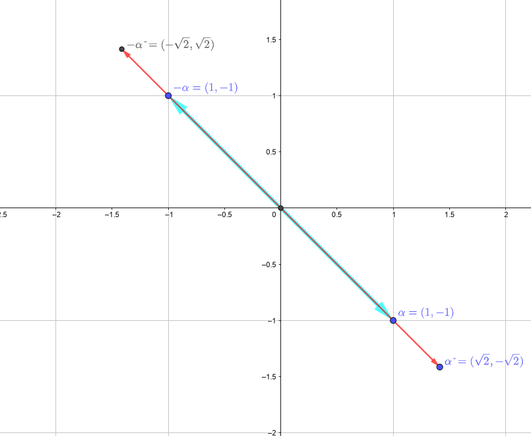

- $A_2$: Writing $\Phi(A_2) = \left\{{e_1 - e_2, e_1 - e_3, e_2 - e_1, e_2 - e_3, e_3 - e_1, e_3 - e_2}\right\} \subseteq {\mathbf{R}}^3$, noting that every root has length $\sqrt{2}$, the dual results in a scaled version of $A_2$:

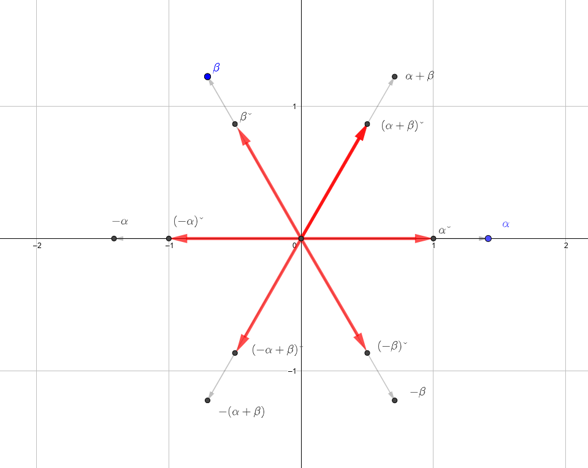

- $B_2$: Let $\Phi(B_2) = \left\{{e_1, -e_1, e_2, -e_2, e_1 + e_2, e_1 - e_2, -e_1 + e_2, -e_1 -e_2}\right\}$ with $\alpha = e_1$ the short root at $\beta = -e_1 + e_2$ the long root, taking the dual fixes the short roots $\pm e_1$ and $\pm e_2$, and normalizes the lengths of the long roots $\pm e_1 \pm e_2$ to 1:

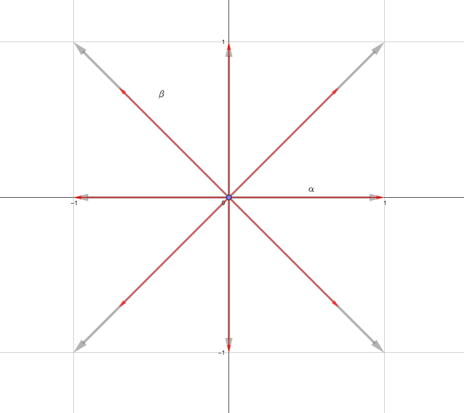

- $G_2$: $\Phi(G_2)$ is shown here in gray, with $\Phi(G_2) {}^{ \vee }$ in green:

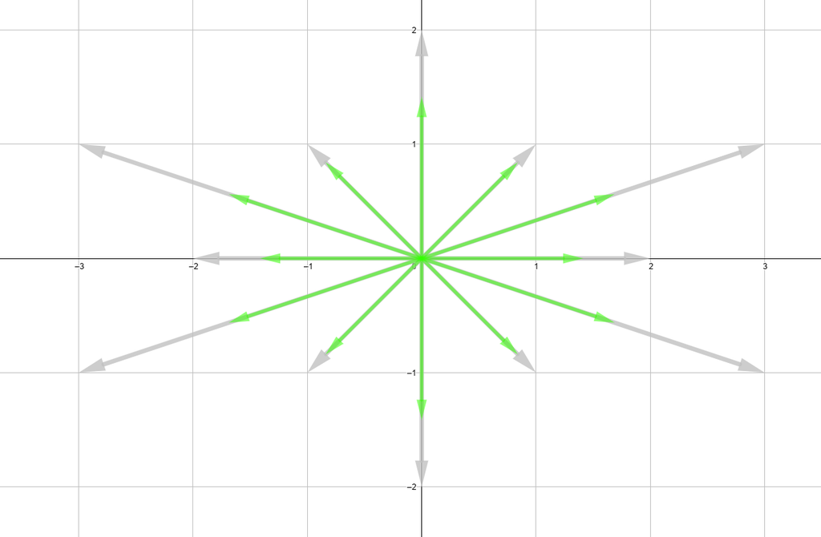

In Table 1, show that the order of $\sigma_\alpha \sigma_\beta$ in $\mathcal{W}$ is (respectively) $2,3,4,6$ when $\theta=\pi / 2, \pi / 3$ (or $2 \pi / 3$ ), $\pi / 4$ (or $3 \pi / 4$ ), $\pi / 6$ (or $5 \pi / 6$ ).

> Note that $\sigma_\alpha \sigma_\beta=$ rotation through $2 \theta$.

Given the hint, this is immediate: if $s_\alpha s_\beta = R_{2\theta}$ is a rigid rotation through an angle of $2\theta$, then it’s clear that
$$\begin{align*}
R_{2 \cdot {\pi \over 2}}^2 = R_{2 \cdot {\pi \over 3}}^3 = R_{2\cdot {\pi \over 4}}^4 = R_{2\cdot {\pi \over 6}}^6 = \operatorname{id}
,\end{align*}
since these are all rotations through an angle of \(2\pi\).$$

To prove the hint, note that in any basis, a reflection has determinant $-1$ since it fixes an $n-1{\hbox{-}}$dimensional subspace (the hyperplane $H_\alpha$ of reflection) and negates its 1-dimensional complement (generated by the normal to $H_\alpha$). On the other hand, $\operatorname{det}(s_\alpha s_\beta) = (-1)^2 = 1$ and is an isometry that only fixes the intersection $H_\alpha = H_\beta = \left\{{\mathbf{0}}\right\}$, so it must be a rotation.

To see that this is a rotation through an angle of exactly $2\theta$, consider applying $s_\beta\circ s_\alpha$ to a point $P$. Letting $H_\alpha, H_\beta$ by the corresponding hyperplanes. We then have the following geometric situation:

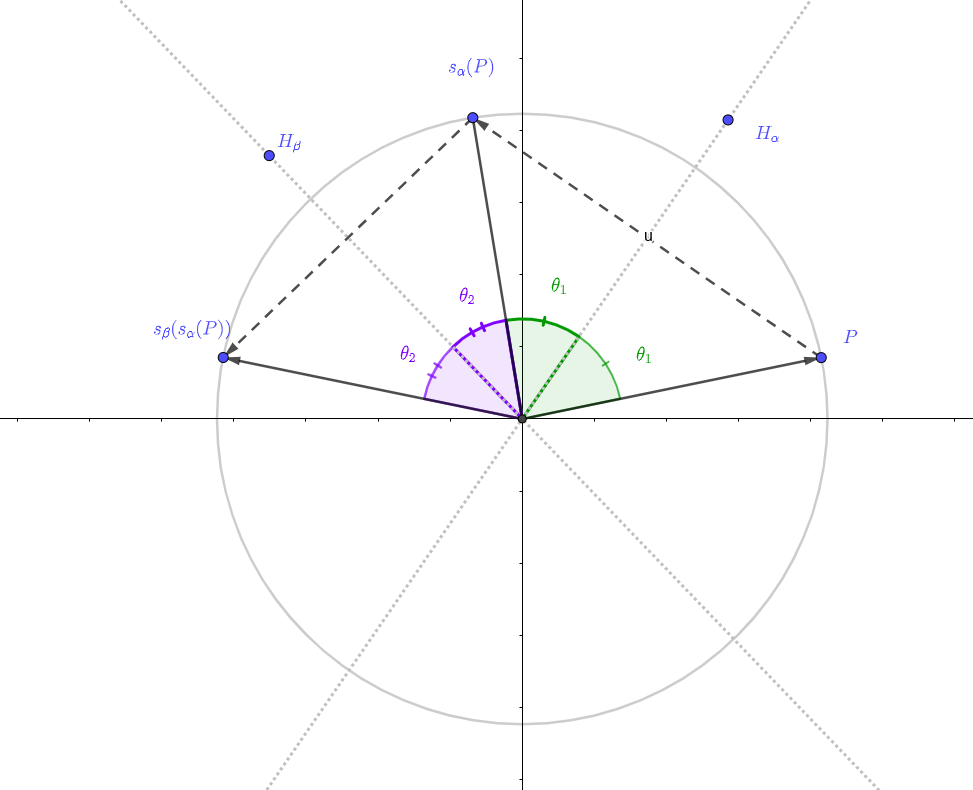

We then have $\theta_1 + \theta_2 = \theta$, noting that the angle between $\alpha$ and $\beta$ is equal to the angle between the hyperplanes $H_\alpha, H_\beta$. The total angle measure between $P$ and $s_\beta(s_\alpha(P))$ is then $2\theta_1 + 2\theta_2 = 2\theta$.

Prove that the respective Weyl groups of $A_1 \times A_1, A_2, B_2, G_2$ are dihedral of order $4,6,8,12$. If $\Phi$ is any root system of rank 2 , prove that its Weyl group must be one of these.

In light of the fact that
$$\begin{align*}
D_{2n} = \left\langle{s, r {~\mathrel{\Big\vert}~}r^n = s^2 = 1, srs^{-1}= r^{-1}}\right\rangle
\end{align*}
where \(r\) is a rotation and \(s\) is a reflection, for the remainder of this problem, let \(s \mathrel{\vcenter{:}}= s_\alpha\) and \(r \mathrel{\vcenter{:}}= s_\alpha s_\beta\) after choosing roots \(\alpha\) and \(\beta\).$$

- $A_1\times A_1$: we have $\Phi(A_2) = \pm e_1, \pm e_2$, and setting $\alpha = e_1, \beta = e_2$ yields $\theta = \pi/2$. We have
  $$\begin{align*}
  {\mathcal{W}}(A_2) = \left\{{\operatorname{id}, s_{\alpha}, s_{\beta}, s_\alpha s_\beta}\right\}
  \end{align*}
  where \(s_{\alpha}^2 = s_{\beta}^2 = 1\), \(s_\alpha s_\beta\) is rotation through \(2\theta = \pi\) radians, and \((s_\alpha s_\beta)^2 = \operatorname{id}\). Setting \(r= s_\alpha, s= s_\alpha s_\beta\) yields \(r^2 = s^2 = \operatorname{id}\) and \(srs = s\), which are the defining relations for \(D_4\).$$
- $A_2$: there is an inscribed triangle in the regular hexagon formed by the convex hull of the roots (see the dotted triangle below), and the reflections $s_\alpha$ about the hyperplanes $H_\alpha$ restrict to precisely the symmetries of this triangle, yielding $D_{6}$:

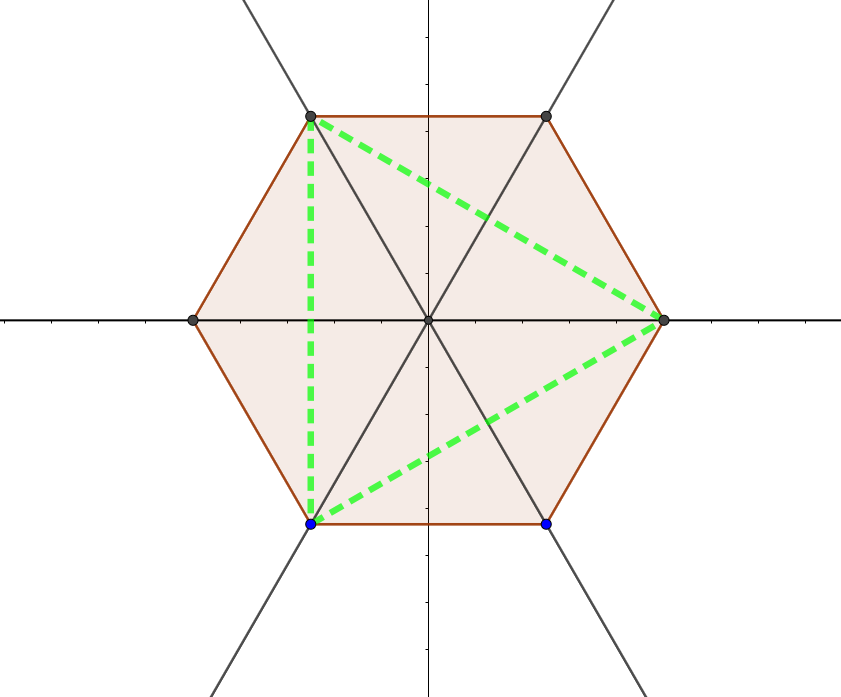

  Alternatively, choose a simple system $\Delta = \left\{{\alpha= e_1, \beta= -e_1 - e_2}\right\}$, then ${\mathcal{W}}(A_2) = \left\langle{s_\alpha, s_\alpha s_\beta}\right\rangle$ is enough to generate the Weyl group. Since we have $s \mathrel{\vcenter{:}}= s_\alpha \implies s^2 = 1$ and $r\mathrel{\vcenter{:}}= s_\alpha s_\beta \implies r_3 = 1$ (since $\theta = \pi/3$), these satisfy the relations of $D_6$.
- $B_2$: there is similarly a square on which the hyperplane reflections act on, highlighted with dotted lines here:

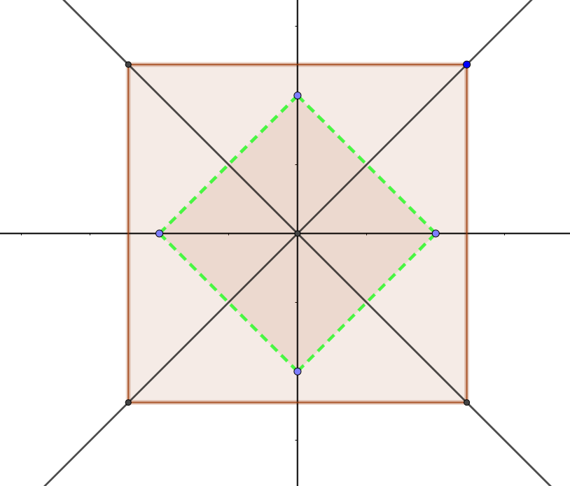

  Since the $s_\alpha$ act faithfully as the symmetries of a square, we have ${\mathcal{W}}(B_2)\cong D_{8}$. Alternatively, take $\alpha = e_1$ and $\beta = -e_1 + e_2$ and set $s = s_\alpha, r = s_\alpha s_\beta$. Then ${\mathcal{W}}(B_2) = \left\langle{s, r}\right\rangle$ and since $s^2 = r^4 = e$ (since here $\theta = \pi/4$) and they satisfy the proper commutation relation, this yields precisely the relations for $D_{2n}, n=4$.
- $G_2$: In this case, the convex hull of the short roots form a hexagon, on which the hyperplane reflections precisely restrict to symmetries:

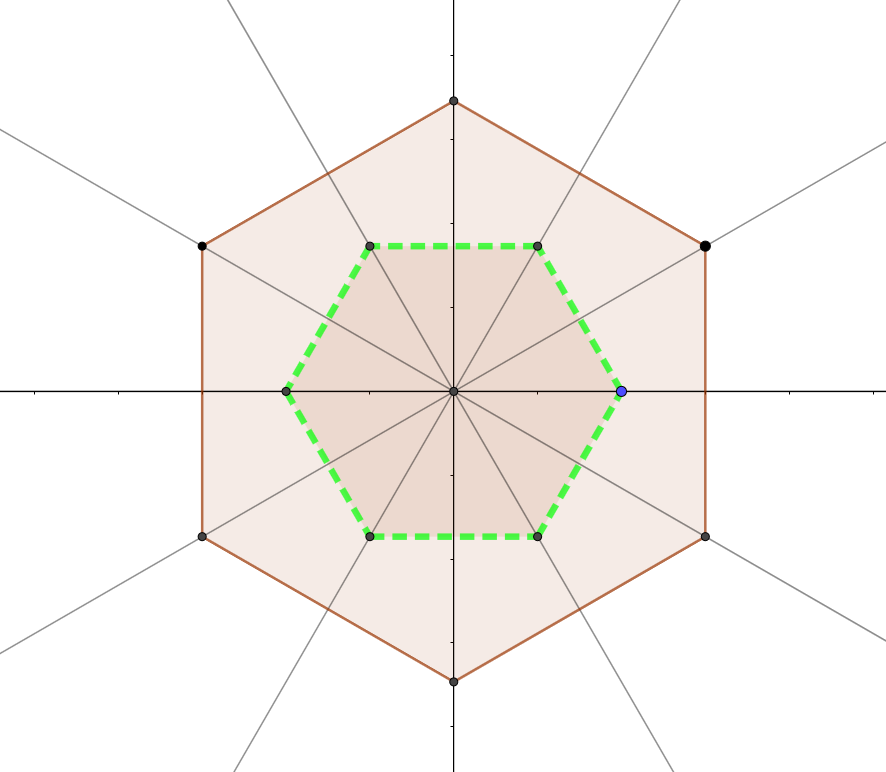

  This yields ${\mathcal{W}}(G_2)\cong D_{12}$. Alternatively, take $\alpha = e_1$ and $\beta$ the long root in quadrant II, set $s = s_\alpha, r= s_\alpha s_\beta$, then $s^2 = r^6 = 1$ since $\theta = \pi/6$ and again the commutation relations for $D_{2n}, n=6$ are satisfied.

## 51.2 Section 10

Let $\Phi {}^{ \vee }$ be the dual system of $\Phi, \Delta {}^{ \vee }=\left\{\alpha {}^{ \vee }\mathrel{\Big|}\alpha \in \Delta\right\}$. Prove that $\Delta {}^{ \vee }$ is a base of $\Phi {}^{ \vee }$.

> Compare Weyl chambers of $\Phi$ and $\Phi {}^{ \vee }$.

Suppose that $\Delta$ is a base of $\Phi$. We can use the fact that bases are in bijective correspondence with Weyl chambers via the correspondence
$$\begin{align*}
\Delta \to \mathrm{WC}(\Delta) \mathrel{\vcenter{:}}=\left\{{v\in {\mathbb{E}}{~\mathrel{\Big\vert}~}(v, \delta) > 0 \,\, \forall \delta\in \Delta}\right\}
,\end{align*}
sending \(\Delta\) to all of the vectors making an acute angle with all simple vectors \(\delta \in \Delta\), or equivalently the intersection of the positive half-spaces formed by the hyperplanes \(H_{\delta}\) for \(\delta\in \Delta\).$$

The claim is that $\mathrm{WC}(\Delta {}^{ \vee }) = \mathrm{WC}(\Delta)$, i.e. the Weyl chamber is preserved under taking duals. This follows the fact that if $v\in \mathrm{WC}(\Delta)$, then $(v,\delta)> 0$ for all $\delta\in \Delta$. Letting $\delta {}^{ \vee }\in \Delta {}^{ \vee }$, we have
$$\begin{align*}
(v,\delta {}^{ \vee }) > \qty{v, {2 \over (\delta, \delta)}\delta } = {2 (v, \delta) \over (\delta,\delta)} > 0
\end{align*}
using that every term in the last step is non-negative. Since this works for every \(\delta {}^{ \vee }\in \Delta {}^{ \vee }\), this yields \(v\in \mathrm{WC}(\Delta {}^{ \vee })\), and a similar argument shows the reverse containment. So \(\Delta {}^{ \vee }\) corresponds to a fundamental Weyl chamber and thus a base.$$

Prove that there is a unique element $\sigma$ in $\mathcal{W}$ sending $\Phi^{+}$to $\Phi^{-}$(relative to $\Delta$ ). Prove that any reduced expression for $\sigma$ must involve all $\sigma_\alpha(\alpha \in \Delta)$. Discuss $\ell(\sigma)$.

The existence and uniqueness of such an element follows directly from the fact that $W$ acts simply transitively on the set of bases, and since $\Delta$ and $-\Delta$ are both bases, there is some $w_0\in W$ such that $w_0(\Delta) = - \Delta$ and consequently $w_0(\Phi^+) = \Phi^-$. Since $\ell(\alpha) = n(\alpha) \leq {\sharp}\Phi^+$ for any root $\alpha$ and $n(w_0) = {\sharp}\Phi^+$ by definition, $w_0$ must be the longest element in $W$, i.e. $\ell(w_0)$ is maximal.

Any reduced expression for $w_0$ must involve all $s_\alpha$ – if not, and say $s_\alpha$ doesn’t occur in any reduced expression for $w_0$, then $w_0$ does not change the sign of $\alpha$ since every $s_\beta$ for $\beta\neq \alpha \in \Delta$ changes the sign of $\beta$ and acts by permutations on $\Phi^+\setminus\left\{{\beta}\right\}$. However, in this case, $w_0' \mathrel{\vcenter{:}}= w_0s_\alpha$ satisfies $n(w_0') = n(w_0) + 1$ since $w_0'$ necessarily changes the sign of $\alpha$, contradicting maximality of $w_0$.

Finally, we have $\ell(w_0) = n(w_0) = {\sharp}\Phi^+$.

## 51.3 Section 11

Use the algorithm of (11.1) to write down all roots for $G_2$.

Do the same for $C_3$:
$$\begin{align*}
\left(\begin{array}{rrr}2 & -1 & 0 \\ -1 & 2 & -1 \\ 0 & -2 & 2\end{array}\right)
\end{align*}$$

Note that it suffices to find all positive roots, since $\Phi = \Phi^+ {\textstyle\coprod}\Phi^-$ once a simple system $\Delta$ is chosen. Since ${\sharp}\Phi(G_2) = 12$, it thus suffices to find 6 positive roots. For $G_2$, the Dynkin diagram indicates one long and one short root, so let $\alpha$ be short and $\beta$ be long. In this system we have
$$\begin{align*}
{\left\langle {\alpha },~{\alpha } \right\rangle}= {\left\langle {\beta },~{\beta } \right\rangle}&= 2 \\
{\left\langle {\alpha },~{\beta } \right\rangle}&= -1 \\
{\left\langle {\beta },~{\alpha } \right\rangle}&= -3
.\end{align*}$$

Combining these yields 6 positive roots:
$$\begin{align*}
\Phi^+(G_2) = \left\{{ \alpha, \alpha+ \beta, \beta, \beta+ 2 \alpha, \beta+ 3 \alpha, 2 \beta +3 \alpha}\right\}
.\end{align*}$$

For $C_3$, there are $2\cdot 3^2 = 18$ total roots and thus 9 positive roots to find. Let $\alpha, \beta, \gamma$ be the three ordered simple roots, then the Cartan matrix specifies
$$\begin{align*}
{\left\langle {\alpha },~{\alpha } \right\rangle}= {\left\langle {\beta },~{\beta } \right\rangle}= {\left\langle {\gamma },~{\gamma } \right\rangle}&= 2 \\
{\left\langle {\beta },~{\alpha } \right\rangle}= {\left\langle {\alpha },~{\beta } \right\rangle}&= -1 \\
{\left\langle {\alpha },~{\gamma } \right\rangle}= {\left\langle {\gamma },~{\alpha } \right\rangle}&= 0 \\
{\left\langle {\beta },~{\gamma } \right\rangle}&= -1 \\
{\left\langle {\gamma },~{\beta } \right\rangle}&= -2
.\end{align*}$$

This yields 9 positive roots:
$$\begin{align*}
\Phi^+(C_3) = \left\{{\alpha, \beta, \gamma, \alpha + \beta, \gamma + \beta, \gamma+ 2 \beta, \alpha+ \beta+ \gamma, \alpha+ 2 \beta + \gamma, \alpha + 3 \alpha + \gamma}\right\}
.\end{align*}$$

# 52 Problem Set 6

## 52.1 Section 17

## 52.2 Section 18

## 52.3 Section 20

> Do one type that is not $A_n$.

# 53 Bibliography

[^1]: You get something interesting if you take the commutator bracket of two upper triangular matrices.
[^2]: The usual product somehow involves “second-order terms,” while the commutator product cancels higher order terms to give something first-order.
[^3]: One should check that this is well-defined.
[^4]: Use the third isomorphism theorem.
[^5]: Lift a series for the quotient, which is eventually in $Z(L)$ since it was zero in the quotient, and then bracketing with $Z(L)$ terminates.
[^6]: If $L^n={n-1} \supseteq L^n=0$ then $[LL^{n-1}] = 0$ and thus $L^{n-1} \subseteq Z(G)$.
[^7]: Note that for arbitrary SESs, the 2-out-of-3 property does not hold for nilpotency, but for the special cases of a quotient by the center it does.
[^8]: Note that the assumption is not that $L$ is a nilpotent algebra, but rather the stronger assumption on endomorphisms.
[^9]: The derived series terminates immediately for an abelian algebra.
[^10]: Associative is $f([xy]z) = f(x [yz])$, sometimes called *invariant*.
[^11]: It turns out that the inverse map of vector spaces $\psi^{-1}: W\to V$ is again a morphism of $L{\hbox{-}}$modules.
[^12]: Note that groups would act on each factor separately, and this is more like a derivative.
[^13]: One might expect an inverse from group theory, which differentiates to a minus sign.
[^14]: See Humphreys p.22.
[^15]: Note that this don’t actually exist! We’re in the middle of a contradiction.
[^16]: This fails for infinite dimensional modules, e.g. Verma modules. The highest weight can be any complex number.
[^17]: More generally,
    $$\begin{align*}
    {2 (\lambda, \alpha)\over (\alpha, \alpha) } = \lambda(h_ \alpha) \qquad\forall \alpha\in \Phi
    .\end{align*}
    ↩︎$$
[^18]: Note that ${\mathfrak{sl}}_2$ has a basis $\left\{{x,h,y}\right\}$ but is freely generated by $x,y$ since $h=[xy]$.
[^19]: $W_L$ is $W$ made into a Lie algebra via $[xy] = xy-yx$.
[^20]: If $x$ is not diagonal, one can use that $x$ is diagonalizable over ${ \mathbf{F} }$ since $x$ has distinct eigenvalues in ${ \mathbf{F} }$. So one can reduce to the diagonal case by a change-of-basis of ${ \mathbf{F} }^n$ that diagonalizes $x$.
[^21]: Corollary C states that if $L$ is solvable then every $x\in L^{(1)}$ is ad-nilpotent, and thus $L^{(1)}$ is nilpotent.
[^22]: Examples: $L$ abelian, $L$ semisimple, $L=\mathfrak{g l}_n({ \mathbf{F} })$.
[^23]: If ad $L \neq 0$, use Weyl’s Theorem.